# Исследование развития индустрии игр в начале XXI века

- **Автор**: [Ковальчук Василий](https://cv.kov.app/data)
- **Дата**: 13.04.2025

### Цели и задачи проекта

**Цель**: изучить объёмы продаж игр разных жанров и региональные предпочтения игроков в разрезе игровых платформ.

**Период**: с 2000 по 2013 год включительно

**Особенности**: акцент исследования должен быть сделан на играх в жанре RPG

**Задачи**:

- категоризация по оценкам игр пользователями и экспертами
- выделить ТОП-7 платформ по количеству выпущенных игр

### Описание данных

Данные для анализа предоставлены в текстовом формате `CSV`, поэтому следует уделить особое внимание на особенности формата:

- возможные ошибки при импорте из-за использования в данных разделителя - запятой;
- неправильная обработка спецсимволов - перенос строки, конец линии и т.п.;
- неправильное автоматическое приведение типов из-за отсутствия в `CSV` информации о типе данных.

Данные собраны из открытых источников, требуется всесторонняя оценка их качества, анализ корректности и полноты заполнения.

Данные содержат информацию о продажах игр разных жанров и платформ, а также пользовательские и экспертные оценки игр:

- `Name` — название игры.
- `Platform` — название платформы.
- `Year of Release` — год выпуска игры.
- `Genre` — жанр игры.
- `NA sales` — продажи в Северной Америке (в миллионах проданных копий).
- `EU sales` — продажи в Европе (в миллионах проданных копий).
- `JP sales` — продажи в Японии (в миллионах проданных копий).
- `Other sales` — продажи в других странах (в миллионах проданных копий).
- `Critic Score` — оценка критиков (от 0 до 100).
- `User Score` — оценка пользователей (от 0 до 10).
- `Rating` — рейтинг организации ESRB (англ. Entertainment Software Rating Board). Эта ассоциация определяет рейтинг компьютерных игр и присваивает им подходящую- возрастную категорию.

### Содержимое проекта

- Загрузка и знакомство с данными
- Корректировка индекса и исправление типов
- Анализ пропусков и их обработка на его основе анализа
- Поиск и обработка дубликатов
- Подготовка среза данных на основе требований заказчика
- Категоризация числовых данных на основании запроса заказчика
- Ответы на обозначенные вопросы
- Подведение итогов

## 1. Загрузка данных

Загружаем необходимые библиотеки Python (мы ограничены в версиях окружением **Яндекс.Практикума**)

```python
import sys

import pandas as pd
import numpy as np
import fuzzywuzzy
from IPython.display import display_markdown

import seaborn as sns
import matplotlib
import matplotlib.pyplot as plt
import matplotlib.patches as mpatches

import sklearn

print(
    f"python: {'.'.join([str(group) for group in sys.version_info][:2])}",
    f"pandas: {pd.__version__}",
    f"numpy: {np.__version__}",
    f"matplotlib: {matplotlib.__version__}",
    f"scikit-learn: {sklearn.__version__}",
    sep="\n"
)
```

```
python: 3.9
pandas: 1.2.4
numpy: 1.20.1
matplotlib: 3.3.4
scikit-learn: 0.24.1
```

Настраиваем некоторые параметры библиотек

```python
# увеличиваем лимит отображения строк и столбцов
pd.options.display.max_columns = 200
pd.options.display.max_rows = 200
# увеличиваем качество генерируемых изображений
matplotlib.rcParams['figure.dpi'] = 300
```

Загружаем датасет

```python
df = pd.read_csv("https://code.s3.yandex.net/datasets/new_games.csv")
```

Знакомство с данными

```python
def meet_the_data(df: pd.DataFrame) -> None:
    display_markdown("__Общая информация о датасете__", raw=True)
    df.info(show_counts=True, verbose=True)
    display(df.describe())
    display_markdown("---\n__Уникальные значения__", raw=True)
    display(
        pd.concat(
            [df.nunique().rename("Кол-во"), (df.nunique().rename("Доля") / df.shape[0])],
            axis=1,
        ).rename_axis('Колонка').style.format(formatter="{:.2%}", subset=['Доля'])
    )
    display_markdown("---\n__Первые пять строк__", raw=True)
    display(df.head(10))
```

```python
# сохраняем изначальный размер для анализа количества удалённых строк на поздних этапах исследования
df_size = df.shape
```

```python
meet_the_data(df)
```

**Общая информация о датасете**

```
<class 'pandas.core.frame.DataFrame'>
RangeIndex: 16956 entries, 0 to 16955
Data columns (total 11 columns):
 #   Column           Non-Null Count  Dtype
---  ------           --------------  -----
 0   Name             16954 non-null  object
 1   Platform         16956 non-null  object
 2   Year of Release  16681 non-null  float64
 3   Genre            16954 non-null  object
 4   NA sales         16956 non-null  float64
 5   EU sales         16956 non-null  object
 6   JP sales         16956 non-null  object
 7   Other sales      16956 non-null  float64
 8   Critic Score     8242 non-null   float64
 9   User Score       10152 non-null  object
 10  Rating           10085 non-null  object
dtypes: float64(4), object(7)
memory usage: 1.4+ MB
```

|  | Year of Release | NA sales | Other sales | Critic Score |
| --- | --- | --- | --- | --- |
| count | 16681.000000 | 16956.000000 | 16956.000000 | 8242.000000 |
| mean | 2006.485522 | 0.262023 | 0.047087 | 68.926717 |
| std | 5.873102 | 0.808654 | 0.185577 | 13.944565 |
| min | 1980.000000 | 0.000000 | 0.000000 | 13.000000 |
| 25% | 2003.000000 | 0.000000 | 0.000000 | 60.000000 |
| 50% | 2007.000000 | 0.080000 | 0.010000 | 71.000000 |
| 75% | 2010.000000 | 0.240000 | 0.030000 | 79.000000 |
| max | 2016.000000 | 41.360000 | 10.570000 | 98.000000 |

**Уникальные значения**

| Колонка | Кол-во | Доля |
| --- | --- | --- |
| Name | 11559 | 68.17% |
| Platform | 31 | 0.18% |
| Year of Release | 37 | 0.22% |
| Genre | 24 | 0.14% |
| NA sales | 402 | 2.37% |
| EU sales | 308 | 1.82% |
| JP sales | 245 | 1.44% |
| Other sales | 155 | 0.91% |
| Critic Score | 82 | 0.48% |
| User Score | 96 | 0.57% |
| Rating | 8 | 0.05% |

|  | Name | Platform | Year of Release | Genre | NA sales | EU sales | JP sales | Other sales | Critic Score | User Score | Rating |
| --- | --- | --- | --- | --- | --- | --- | --- | --- | --- | --- | --- |
| 0 | Wii Sports | Wii | 2006.0 | Sports | 41.36 | 28.96 | 3.77 | 8.45 | 76.0 | 8 | E |
| 1 | Super Mario Bros. | NES | 1985.0 | Platform | 29.08 | 3.58 | 6.81 | 0.77 | NaN | NaN | NaN |
| 2 | Mario Kart Wii | Wii | 2008.0 | Racing | 15.68 | 12.76 | 3.79 | 3.29 | 82.0 | 8.3 | E |
| 3 | Wii Sports Resort | Wii | 2009.0 | Sports | 15.61 | 10.93 | 3.28 | 2.95 | 80.0 | 8 | E |
| 4 | Pokemon Red/Pokemon Blue | GB | 1996.0 | Role-Playing | 11.27 | 8.89 | 10.22 | 1.00 | NaN | NaN | NaN |
| 5 | Tetris | GB | 1989.0 | Puzzle | 23.20 | 2.26 | 4.22 | 0.58 | NaN | NaN | NaN |
| 6 | New Super Mario Bros. | DS | 2006.0 | Platform | 11.28 | 9.14 | 6.5 | 2.88 | 89.0 | 8.5 | E |
| 7 | Wii Play | Wii | 2006.0 | Misc | 13.96 | 9.18 | 2.93 | 2.84 | 58.0 | 6.6 | E |
| 8 | New Super Mario Bros. Wii | Wii | 2009.0 | Platform | 14.44 | 6.94 | 4.7 | 2.24 | 87.0 | 8.4 | E |
| 9 | Duck Hunt | NES | 1984.0 | Shooter | 26.93 | 0.63 | 0.28 | 0.47 | NaN | NaN | NaN |

### Предварительные выводы и на что стоит обратить внимание при анализе

- Всего в датасете **16956** записей, названия колонок соответствуют полученному описанию данных.
- При загрузке колонок `Year of Release` и `Critic Score` были преобразованы во `float64`, что не соответствует описанию данных (год должен быть целочисленным; оценка критиков от **0** до **100**, вероятно, тоже).
- При загрузке колонок `User Score`, `EU sales`, `JP sales` они были преобразованы в тип `object`, что может указывать на наличие нечисловых значений.
- Больше **30%** значений колонки `Name` неуникальны, хотя должны быть. Это может быть связано с выходом одной и той же игры на нескольких платформах, переизданием игр в разные года или дубликатах.
- Данные о продажах в колонках `NA sales`, `EU sales`,`JP sales`,`Other sales` имеют низкое количество уникальных значений (меньше **3%** для у каждой из колонок). Данные в них храняться с точностью до **10** тысяч проданных копий, что может говорить о низких продажах большинства наименований, но может быть вызвано и ошибками в данных.
- В колонке `Rating` восемь уникальных значений, хотя нам известно о семи возможных категориях.
- В колонке `Genre` присутствуют такие жанры как **Racing** и **Sports**, что может говорить об их принадлежности к иерархическому списку (жанры разделены на поджанры - одно множество входит в другое)
- Бо́льшая часть пропусков в колонках `Critic Score`, `User Score`, `Rating`

## 2. Проверка ошибок

### 2.1. Колонки

Названия столбцов содержат пробелы, поэтому к ним нельзя будет обратиться как к атрибутам датафрейма. Преобразуем в `snake_case` заменив пробелы на символ подчёркивания и приведя всё в нижний регистр.

```python
print("Оригинальные названия колонок:", df.columns.to_list())
df.columns = df.columns.str.lower().str.replace(pat=" ", repl="_")
print("После преобразования в `snake_case`:", df.columns.to_list())
```

```
Оригинальные названия колонок: ['Name', 'Platform', 'Year of Release', 'Genre', 'NA sales', 'EU sales', 'JP sales', 'Other sales', 'Critic Score', 'User Score', 'Rating']
После преобразования в `snake_case`: ['name', 'platform', 'year_of_release', 'genre', 'na_sales', 'eu_sales', 'jp_sales', 'other_sales', 'critic_score', 'user_score', 'rating']
```

### 2.2. Типы данных

При первом знакомстве мы выделили несколько колонок, тип данных которых не соответствует их описанию. Взлянем на них подближе.

#### Целочисленный

По описанию целочисленные значения принимают колонки `year_of_release` и `critic_score`, но они загружены как числа с плавающей точкой. Проверим уникальные значения и пропуски.

```python
int_columns = ["year_of_release", "critic_score"]  # сохраняем на будущее
for col in int_columns:
    print(col)
    display(
        pd.DataFrame(df[[col]].value_counts().rename("count")).T
    ) # транспонируем для более компактного вывода
    display_markdown(f"NA count in {col}: {df[col].isna().sum()}", raw=True)
```

```
year_of_release
```

| year_of_release | 2009.0 | 2008.0 | 2010.0 | 2007.0 | 2011.0 | 2006.0 | 2005.0 | 2002.0 | 2003.0 | 2004.0 | 2012.0 | 2015.0 | 2014.0 | 2013.0 | 2016.0 | 2001.0 | 1998.0 | 2000.0 | 1999.0 | 1997.0 | 1996.0 | 1995.0 | 1994.0 | 1993.0 | 1981.0 | 1992.0 | 1991.0 | 1982.0 | 1986.0 | … |
| --- | --- | --- | --- | --- | --- | --- | --- | --- | --- | --- | --- | --- | --- | --- | --- | --- | --- | --- | --- | --- | --- | --- | --- | --- | --- | --- | --- | --- | --- | --- |
| count | 1450 | 1445 | 1279 | 1218 | 1149 | 1020 | 950 | 839 | 789 | 771 | 670 | 612 | 584 | 552 | 507 | 491 | 384 | 357 | 341 | 293 | 267 | 220 | 121 | 62 | 46 | 43 | 42 | 37 | 22 | … |

NA count in year_of_release: 275

```
critic_score
```

| critic_score | 70.0 | 71.0 | 75.0 | 73.0 | 78.0 | 80.0 | 76.0 | 74.0 | 72.0 | 77.0 | 81.0 | 68.0 | 79.0 | 69.0 | 82.0 | 83.0 | 66.0 | 65.0 | 84.0 | 67.0 | 63.0 | 62.0 | 64.0 | 61.0 | 60.0 | 59.0 | 58.0 | 85.0 | 86.0 | … |
| --- | --- | --- | --- | --- | --- | --- | --- | --- | --- | --- | --- | --- | --- | --- | --- | --- | --- | --- | --- | --- | --- | --- | --- | --- | --- | --- | --- | --- | --- | --- |
| count | 257 | 256 | 248 | 245 | 243 | 240 | 235 | 230 | 229 | 228 | 220 | 220 | 219 | 215 | 211 | 210 | 209 | 195 | 184 | 183 | 182 | 172 | 170 | 168 | 159 | 159 | 153 | 152 | 139 | … |

NA count in critic_score: 8714

Значения колонок `year_of_release` и `critic_score` являются целочисленными, но преобразованы в числа с плавающей точкой из-за ограничений типа `numpy.int64`, используемый Pandas по умолчанию. Приведём колонки к типу `pd.Int64Dtype`, который [поддерживает](https://pandas.pydata.org/docs/user_guide/integer_na.html) пропуски в целочисленных колонках.

```python
df[int_columns] = df[int_columns].astype(pd.Int64Dtype())
```

Также обращаем внимание, что данные колонка `year_of_release` принимает ограниченное количество значений, поэтому с ней будет удобно работать как с колонкой категориального ординального типа. Преобразуем их в категории в последующих шагах.

#### Вещественный

Колонки `na_sales` и `other_sales` были корректно преобразованы к вещественному типу, тогда как `user_score`, `eu_sales`, `jp_sales` были преобразованы к типу `object`. Проверим типы значений в объектных колонках.

```python
float_columns = ["na_sales", "eu_sales", "jp_sales", "other_sales", "user_score"]
# NB: метод `applymap` удалён из Pandas с версии 2.1.0
df[float_columns].select_dtypes('object').applymap(type).apply(pd.unique)
```

```
eu_sales                       [<class 'str'>]
jp_sales                       [<class 'str'>]
user_score    [<class 'str'>, <class 'float'>]
dtype: object
```

Нет других данных помимо строковых и числовых. При этом в колонках `eu_sales` и `jp_sales` данные только строковые, а в колонке `user_score` и строковые и числовые. Посмотрим на уникальные значения и их частоту. Также выведем частоту типов в колонке `user_score`.

```python
display_markdown('__Уникальные значения__', raw=True)

for col in df[float_columns].select_dtypes('object').columns:
    display(
        pd.DataFrame(df[[col]].value_counts().rename("count")).T
    ) # транспонируем для более компактного вывода
    print("NA count:", df[col].isna().sum())

display_markdown('---', raw=True)
display_markdown('__Частота типов в `user_score`__', raw=True)
display(df['user_score'].apply(type).value_counts())

display_markdown('__Уникальные значения типа `float` в колонке `user_score`__', raw=True)
mask_float = df['user_score'].apply(lambda x: isinstance(x, float))
display(df['user_score'][mask_float].unique())
```

**Уникальные значения**

| eu_sales | 0.0 | 0.01 | 0.02 | 0.03 | 0.04 | 0.05 | 0.06 | 0.07 | 0.08 | 0.09 | 0.1 | 0.12 | 0.11 | 0.13 | 0.15 | 0.16 | 0.14 | 0.17 | 0.2 | 0.18 | 0.19 | 0.21 | 0.22 | 0.27 | 0.23 | 0.25 | 0.24 | 0.26 | 0.29 | … |
| --- | --- | --- | --- | --- | --- | --- | --- | --- | --- | --- | --- | --- | --- | --- | --- | --- | --- | --- | --- | --- | --- | --- | --- | --- | --- | --- | --- | --- | --- | --- |
| count | 5950 | 1522 | 1328 | 939 | 720 | 570 | 413 | 364 | 316 | 276 | 238 | 237 | 230 | 195 | 187 | 162 | 156 | 131 | 126 | 114 | 114 | 103 | 100 | 86 | 82 | 79 | 74 | 63 | 60 | … |

1 rows × 308 columns

```
NA count: 0
```

| jp_sales | 0.0 | 0.02 | 0.01 | 0.03 | 0.04 | 0.05 | 0.06 | 0.07 | 0.08 | 0.09 | 0.1 | 0.12 | 0.11 | 0.13 | 0.14 | 0.15 | 0.16 | 0.19 | 0.17 | 0.2 | 0.18 | 0.21 | 0.22 | 0.3 | 0.23 | 0.26 | 0.28 | 0.25 | 0.27 | … |
| --- | --- | --- | --- | --- | --- | --- | --- | --- | --- | --- | --- | --- | --- | --- | --- | --- | --- | --- | --- | --- | --- | --- | --- | --- | --- | --- | --- | --- | --- | --- |
| count | 10680 | 754 | 714 | 554 | 402 | 325 | 298 | 232 | 220 | 157 | 156 | 149 | 147 | 125 | 101 | 91 | 85 | 81 | 73 | 68 | 56 | 55 | 55 | 54 | 52 | 49 | 47 | 45 | 45 | … |

1 rows × 245 columns

```
NA count: 0
```

| user_score | tbd | 7.8 | 8 | 8.2 | 8.3 | 7.9 | 8.5 | 7.5 | 8.1 | 7.7 | 7.3 | 8.4 | 7 | 7.6 | 7.4 | 8.6 | 6.8 | 8.7 | 8.8 | 7.1 | 7.2 | 8.9 | 6.6 | 6.9 | 6.3 | 6 | 6.7 | 6.5 | 9 | … |
| --- | --- | --- | --- | --- | --- | --- | --- | --- | --- | --- | --- | --- | --- | --- | --- | --- | --- | --- | --- | --- | --- | --- | --- | --- | --- | --- | --- | --- | --- | --- |
| count | 2464 | 329 | 292 | 282 | 257 | 255 | 254 | 254 | 246 | 243 | 238 | 226 | 225 | 223 | 220 | 213 | 199 | 188 | 187 | 183 | 168 | 156 | 149 | 146 | 139 | 130 | 128 | 125 | 121 | … |

```
NA count: 6804
```

**Частота типов в `user_score`**

```
<class 'str'>      10152
<class 'float'>     6804
Name: user_score, dtype: int64
```

**Уникальные значения типа `float` в колонке `user_score`**

```
array([nan], dtype=object)
```

Все значения `NaN` в `user_score` в типе `float64`, а остальные - в `str`. Беглый визуальный анализ уникальных значений в колонках `eu_sales`, `jp_sales` и `user_score` не выявил наличие аномалий, которые могут помешать привести значения к числовому типу стандартными методами Pandas. При этом, в случае ошибки приведения типа, мы присвоим значение `NaN`. Это позволит нам получить маску для поиска всех значений, которые вызывают ошибку, и проанализировать их отдельно. Заодно сразу попробуем уменьшить размерность данных для оптимизации хранения.

```python
df_float = df[float_columns].apply(pd.to_numeric, errors='coerce', downcast='float')
mask_na_old = df[float_columns].isna()
mask_na_new = df_float.isna()
# Мы получили две маски пропусков до приведения типов и после, которые отличаются
# в тех местах, в которых приведение типов столкнулось с ошибкой и изменило значение
# на `NaN`. Чтобы получить маску этих элементов с ошибками, мы используем
# исключающее `ИЛИ` (`XOR`) от старой и новой маски.
mask_float_error = mask_na_new ^ mask_na_old

for column in float_columns:
    display_markdown(f'__Колонка `{column}`:__', raw=True)
    display(df[column][mask_float_error[column]].value_counts())
```

**Колонка `na_sales`:**

```
Series([], Name: na_sales, dtype: int64)
```

**Колонка `eu_sales`:**

```
unknown    6
Name: eu_sales, dtype: int64
```

**Колонка `jp_sales`:**

```
unknown    4
Name: jp_sales, dtype: int64
```

**Колонка `other_sales`:**

```
Series([], Name: other_sales, dtype: int64)
```

**Колонка `user_score`:**

```
tbd    2464
Name: user_score, dtype: int64
```

Ошибку вызвали несколько строк `unknown` в колонках с данными продаж, а также несколько тысяч строк `tbd` в колонке с пользовательской оценкой. Мы не потеряем информации для анализа, если заменим эти значения на `NaN`, а с пропусками разберёмся в следующих шагах.

```python
df[float_columns] = df_float
del df_float
```

#### Категориальный

По описанию и количеству уникальных значений к категориальным колонкам номинативного типа относятся `platform`, `genre` и `rating`. Также ранее мы определили, что целочисленную колонку `year_of_release` можно считать категориальной ординального типа.

```python
categorical_columns = ['platform', 'genre','rating']
ordinal_columns = ['year_of_release', 'critic_score']

# номинативные категории просто определить ключевым словом `category`
df[categorical_columns] = df[categorical_columns].astype('category')

# для приведения к ординальному типу нужно использовать конструктор категориального
# класса `pd.CategoricalDtype`

# для года используем все значения в интервале от первого до последнего года в наблюдениях
categories_arr = range(df.year_of_release.min(), df.year_of_release.max() + 1)
df.year_of_release = df.year_of_release.astype(pd.CategoricalDtype(categories=categories_arr, ordered=True))
# # для оценки критиков диапазон от 0 до 100, как в описании данных
categories_arr = range(101)
df.critic_score = df.critic_score.astype(pd.CategoricalDtype(categories=categories_arr, ordered=True))
```

Проверим созданные категории

```python
for column in categorical_columns + ordinal_columns:
    display_markdown(f'__Колонка `{df[column].name}`__', raw=True)
    display(df[column].dtype)
```

**Колонка `platform`**

```
CategoricalDtype(categories=['2600', '3DO', '3DS', 'DC', 'DS', 'GB', 'GBA', 'GC', 'GEN',
                  'GG', 'N64', 'NES', 'NG', 'PC', 'PCFX', 'PS', 'PS2', 'PS3',
                  'PS4', 'PSP', 'PSV', 'SAT', 'SCD', 'SNES', 'TG16', 'WS',
                  'Wii', 'WiiU', 'X360', 'XB', 'XOne'],
, ordered=False)
```

**Колонка `genre`**

```
CategoricalDtype(categories=['ACTION', 'ADVENTURE', 'Action', 'Adventure', 'FIGHTING',
                  'Fighting', 'MISC', 'Misc', 'PLATFORM', 'PUZZLE', 'Platform',
                  'Puzzle', 'RACING', 'ROLE-PLAYING', 'Racing', 'Role-Playing',
                  'SHOOTER', 'SIMULATION', 'SPORTS', 'STRATEGY', 'Shooter',
                  'Simulation', 'Sports', 'Strategy'],
, ordered=False)
```

**Колонка `rating`**

```
CategoricalDtype(categories=['AO', 'E', 'E10+', 'EC', 'K-A', 'M', 'RP', 'T'], ordered=False)
```

**Колонка `year_of_release`**

```
CategoricalDtype(categories=range(1980, 2017), ordered=True)
```

**Колонка `critic_score`**

```
CategoricalDtype(categories=range(0, 101), ordered=True)
```

Обращаем внимание, что одни и те жанры представлены в различном регистре. Сразу приведём к единому регистру.

```python
df['genre'] = df['genre'].str.lower().astype('category')
```

### 2.3. Наличие пропусков

#### Анализ

Изучим пропуски в данных

```python
null_stats = (
    df.isna().apply(["sum", "mean"]) # вычисляем
    .T.astype({"sum": "int", "mean": "float"}) # транспонируем и правим типы
    [df.isna().sum() != 0] # фильтруем колонки без пропусков
    .rename(columns={"sum": "Кол-во", "mean": "Доля"}).rename_axis("Колонка") # переименовываем
)

null_stats.style.format(formatter="{:.2%}", subset=["Доля"]) # форматируем доли в проценты
```

| Колонка | Кол-во | Доля |
| --- | --- | --- |
| name | 2 | 0.01% |
| year_of_release | 275 | 1.62% |
| genre | 2 | 0.01% |
| eu_sales | 6 | 0.04% |
| jp_sales | 4 | 0.02% |
| critic_score | 8714 | 51.39% |
| user_score | 9268 | 54.66% |
| rating | 6871 | 40.52% |

Также построим корреляционную матрицу пропусков, чтобы оценить зависимость наличия пропусков в колонках друг от друга

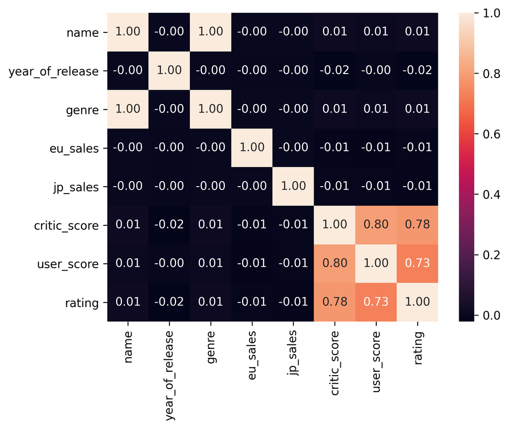

```python
# отфильтровываем колонки, в которых нет пропусков
correlation_matrix = df.loc[:, df.isna().sum() > 0].isna().corr()
sns.heatmap(correlation_matrix, annot=True, fmt=".2f")
```

##### Колонки с долей пропусков до 1%

```
Пропуски в колонках: ['name', 'genre', 'eu_sales', 'jp_sales']
```

|  | name | platform | year_of_release | genre | na_sales | eu_sales | jp_sales | other_sales | critic_score | user_score | rating |
| --- | --- | --- | --- | --- | --- | --- | --- | --- | --- | --- | --- |
| 446 | Rhythm Heaven | DS | 2008 | misc | 0.55 | NaN | 1.93 | 0.13 | 83 | 9.0 | E |
| 467 | Saints Row 2 | X360 | 2008 | action | 1.94 | 0.79 | NaN | 0.28 | 81 | 8.1 | M |
| 661 | NaN | GEN | 1993 | NaN | 1.78 | 0.53 | 0.00 | 0.08 | NaN | NaN | NaN |
| 802 | Dead Rising | X360 | 2006 | action | 1.16 | NaN | 0.08 | 0.20 | 85 | 7.6 | M |
| 819 | UFC 2009 Undisputed | X360 | 2009 | fighting | 1.48 | 0.39 | NaN | 0.19 | 83 | 7.9 | T |
| 1131 | Prince of Persia: Warrior Within | PS2 | 2004 | action | 0.54 | NaN | 0.00 | 0.22 | 83 | 8.5 | M |
| 1132 | Far Cry 4 | XOne | 2014 | shooter | 0.80 | NaN | 0.01 | 0.14 | 82 | 7.5 | M |
| 1379 | Hello Kitty Party | DS | 2007 | misc | 0.78 | 0.51 | NaN | 0.12 | NaN | NaN | E |
| 1394 | Sonic Advance 3 | GBA | 2004 | platform | 0.74 | NaN | 0.08 | 0.06 | 79 | 8.4 | E |
| 1612 | Ratatouille | DS | 2007 | action | 0.49 | NaN | 0.00 | 0.14 | NaN | NaN | NaN |
| 4732 | Castlevania: The Dracula X Chronicles | PSP | 2007 | platform | 0.22 | 0.09 | NaN | 0.07 | 80 | 7.8 | T |
| 14439 | NaN | GEN | 1993 | NaN | 0.00 | 0.00 | 0.03 | 0.00 | NaN | NaN | NaN |

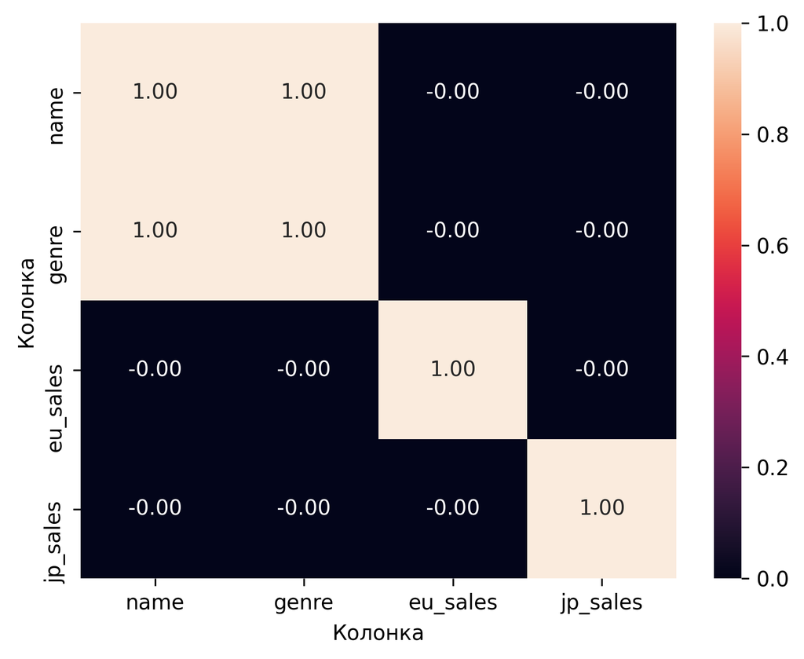

```python
mask = (null_stats['Доля'] < 0.01)
print("Пропуски в колонках:", null_stats[mask].index.to_list())
display(df[df[null_stats[mask].index].isna().any(axis=1)])
correlation_matrix = df.loc[:, null_stats[mask].index].isna().corr()
sns.heatmap(correlation_matrix, annot=True, fmt=".2f")
```

**ВЫВОД**:

- Пропущены наименования всего двух игр, вышедших в **1993** году. Их удаление не повлияет на исследование, потому что нас интересует период с **2000** по **2013**.
- Жанры отсутствуют как у записей без наименования, тоже **1993** года.
- Отсутствующие записи по продажам безопасно удалить, но попробуем восстановить их используя алгоритмы ML.

##### Колонки с долей пропусков от 1% до 5%

```python
mask = (null_stats['Доля'] > 0.01) & (null_stats['Доля'] < 0.05)
print("Пропуски в колонках:", null_stats[mask].index.to_list())
display(null_stats[mask].style.format("{:.2%}", subset=["Доля"]))
display(df[df[null_stats[mask].index].isna().any(axis=1)].sample(10))
```

```
Пропуски в колонках: ['year_of_release']
```

| Колонка | Кол-во | Доля |
| --- | --- | --- |
| year_of_release | 275 | 1.62% |

|  | name | platform | year_of_release | genre | na_sales | eu_sales | jp_sales | other_sales | critic_score | user_score | rating |
| --- | --- | --- | --- | --- | --- | --- | --- | --- | --- | --- | --- |
| 4267 | Circus Atari | 2600 | NaN | action | 0.43 | 0.03 | 0.00 | 0.00 | NaN | NaN | NaN |
| 16184 | PDC World Championship Darts 2008 | DS | NaN | sports | 0.01 | 0.00 | 0.00 | 0.00 | NaN | NaN | NaN |
| 8262 | Otomedius Excellent | X360 | NaN | shooter | 0.13 | 0.00 | 0.04 | 0.01 | 48 | 8.1 | T |
| 7828 | Dead Space 3 | PC | NaN | action | 0.02 | 0.16 | 0.00 | 0.02 | 78 | 6.0 | M |
| 5102 | Hangman | 2600 | NaN | puzzle | 0.35 | 0.02 | 0.00 | 0.00 | NaN | NaN | NaN |
| 15137 | The King of Fighters: Maximum Impact - Maniax | XB | NaN | fighting | 0.02 | 0.01 | 0.00 | 0.00 | NaN | NaN | NaN |
| 659 | Frogger's Adventures: Temple of the Frog | GBA | NaN | adventure | 2.15 | 0.18 | 0.00 | 0.07 | 73 | NaN | E |
| 2802 | WarioWare: Twisted! | GBA | NaN | puzzle | 0.16 | 0.06 | 0.50 | 0.02 | NaN | NaN | NaN |
| 12959 | Tom Clancy's Rainbow Six: Critical Hour | XB | NaN | shooter | 0.04 | 0.01 | 0.00 | 0.00 | 54 | 3.6 | M |
| 7953 | Pet Zombies | 3DS | NaN | simulation | 0.18 | 0.00 | 0.00 | 0.01 | NaN | NaN | T |

Рассмотрим долю пропущенных значений в годе выхода отдельно по жанрам и по рейтингу

**Нулевые значения в колонке `year_of_release` в зависимости от групп в колонках `genre`, `rating`, `platform` и дециля общих продаж**

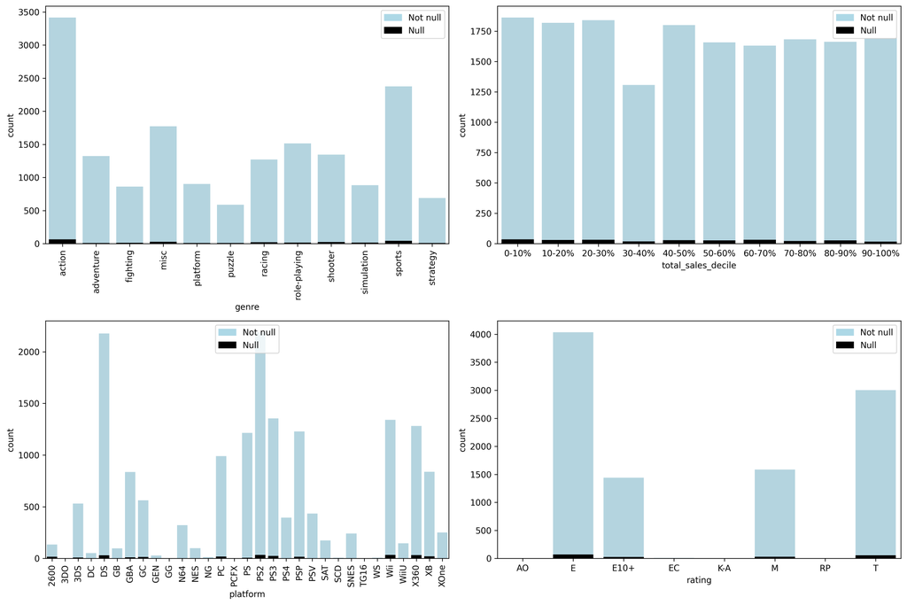

| genre | action | adventure | fighting | misc | platform | puzzle | racing | role-playing | shooter | simulation | sports | strategy |
| --- | --- | --- | --- | --- | --- | --- | --- | --- | --- | --- | --- | --- |
| null_count | 65 | 10 | 12 | 29 | 10 | 11 | 23 | 17 | 27 | 17 | 43 | 11 |
| overall_count | 3418 | 1323 | 862 | 1772 | 904 | 590 | 1273 | 1516 | 1346 | 884 | 2375 | 691 |
| fraction | 1.90% | 0.76% | 1.39% | 1.64% | 1.11% | 1.86% | 1.81% | 1.12% | 2.01% | 1.92% | 1.81% | 1.59% |

| total_sales_decile | 0-10% | 10-20% | 20-30% | 30-40% | 40-50% | 50-60% | 60-70% | 70-80% | 80-90% | 90-100% |
| --- | --- | --- | --- | --- | --- | --- | --- | --- | --- | --- |
| null_count | 36 | 30 | 32 | 19 | 29 | 28 | 33 | 22 | 28 | 18 |
| overall_count | 1863 | 1818 | 1841 | 1307 | 1801 | 1657 | 1630 | 1683 | 1663 | 1693 |
| fraction | 1.93% | 1.65% | 1.74% | 1.45% | 1.61% | 1.69% | 2.02% | 1.31% | 1.68% | 1.06% |

| platform | 2600 | 3DO | 3DS | DC | DS | GB | GBA | GC | GEN | GG | N64 | NES | NG | PC | PCFX | PS | PS2 | PS3 | PS4 | PSP | PSV | SAT | SCD | SNES | TG16 | WS | Wii | WiiU | X360 | … |
| --- | --- | --- | --- | --- | --- | --- | --- | --- | --- | --- | --- | --- | --- | --- | --- | --- | --- | --- | --- | --- | --- | --- | --- | --- | --- | --- | --- | --- | --- | --- |
| null_count | 17 | 0 | 8 | 0 | 30 | 1 | 11 | 14 | 0 | 0 | 3 | 0 | 0 | 18 | 0 | 7 | 35 | 25 | 0 | 17 | 1 | 0 | 0 | 0 | 0 | 0 | 35 | 0 | 32 | … |
| overall_count | 135 | 3 | 530 | 52 | 2177 | 98 | 837 | 563 | 29 | 1 | 323 | 100 | 12 | 990 | 1 | 1215 | 2189 | 1355 | 395 | 1229 | 435 | 174 | 6 | 241 | 2 | 6 | 1340 | 147 | 1281 | … |
| fraction | 12.59% | 0.00% | 1.51% | 0.00% | 1.38% | 1.02% | 1.31% | 2.49% | 0.00% | 0.00% | 0.93% | 0.00% | 0.00% | 1.82% | 0.00% | 0.58% | 1.60% | 1.85% | 0.00% | 1.38% | 0.23% | 0.00% | 0.00% | 0.00% | 0.00% | 0.00% | 2.61% | 0.00% | 2.50% | … |

| rating | AO | E | E10+ | EC | K-A | M | RP | T |
| --- | --- | --- | --- | --- | --- | --- | --- | --- |
| null_count | 0 | 69 | 27 | 0 | 0 | 29 | 2 | 57 |
| overall_count | 1 | 4037 | 1441 | 8 | 3 | 1587 | 3 | 3005 |
| fraction | 0.00% | 1.71% | 1.87% | 0.00% | 0.00% | 1.83% | 66.67% | 1.90% |

```python
def show_nulls_by_groups(df: pd.DataFrame, na_column: str) -> list[pd.DataFrame]:
    """Функция рисует столбчатые диаграммы `null` значений в колонке `na_column`
    датафрема `df` на основе категорий в других колонках и возвращает метрики
    пропусков в данных по этим категориям.

    Колонки определены заранее - "year_of_release", "rating", "platform", "genre",
    "total_sales_decile". Колонка "total_sales_decile" рассчитывается как сумма
    всех колонок продаж игр (колонки с суффиксом "_sales").

    Args:
        df (pd.DataFrame): датафрейм с играми
        na_column (str): колонка в которой считаем пропущенные значения

    Returns:
        list[pd.DataFrame]: список датафремов с метриками "null_count",
        "overall_count", "fraction"
    """
    from itertools import zip_longest

    # исключаем колонку
    columns = {"year_of_release", "rating", "platform", "genre", "total_sales_decile"}.difference({na_column})
    data = df.copy()

    # считаем общие продажи
    data["total_sales"] = df.filter(like="_sales").sum(axis=1)
    # категоризируем колонки по децилям общей суммы продаж во всех регионах
    labels = [f"{i}-{i + 10}%" for i in range(0, 100, 10)]
    data["total_sales_decile"] = pd.qcut(data["total_sales"], q=10, labels=labels)

    # готовив канвас 2х2
    ncols = 2
    nrows = (len(columns) - 1) // ncols + 1
    fig, axes = plt.subplots(nrows=nrows , ncols=ncols)
    fig.set_size_inches(w=15, h=5 * nrows)

    return_stats = []
    for group_column, ax in zip_longest(columns, axes.reshape(-1)):
        if group_column is None:
            ax.remove()
            continue

        data["Missing values"] = data[na_column].isna()

        # отрисовываем один столбец над другим
        sns.countplot(data=data, x=group_column, color='lightblue', ax=ax) # все значения
        sns.countplot(data=data[data['Missing values']], x=group_column, color='black', ax=ax) # только пропущенные

        # легенда
        top_bar = mpatches.Patch(color='lightblue', label='Not null')
        bottom_bar = mpatches.Patch(color='black', label='Null')
        ax.legend(handles=[top_bar, bottom_bar])

        # если много групп, то наклоняем подписи оси на 90°
        if data[group_column].nunique() > 10:
            ax.tick_params(axis="x", rotation=90)

        # метрики возвращаются функцией
        metrics = (
            data
            .groupby(group_column)['Missing values']
            .agg(["sum", "count"])
            .rename(columns={"sum": "null_count", "count": "overall_count"})
        )
        metrics["fraction"] = metrics["null_count"] / metrics["overall_count"]
        return_stats.append(metrics)

    fig.tight_layout()
    plt.show()

    return return_stats

display_markdown(
    "__Нулевые значения в колонке `year_of_release` в зависимости от групп в колонках `genre`, `rating`, `platform` и дециля общих продаж__",
    raw=True,
)

for data in show_nulls_by_groups(df, "year_of_release"):
    display(
        data.T.style
        .format("{:.0f}")
        .format("{:.2%}", subset=pd.IndexSlice[["fraction"], :])
    )
```

Распределение нулевых значений примерно одинаково в различных группах из различных колонок (с количеством наблюдений больше **20**) - **1-3%**. Единственное исключение - платформа **Atari 2600**, в которой **12,59%** пропусков, что объясняется её почтенным возрастом (платформа была выпущена в 1977) - в то время не существовало ни игровой индустрии как таковой, ни необходимости вести учёт выпущенных игр.

При отсутствии других данных, делаем вывод, что пропуски это пропуски типа **MСAR** — полностью случайные пропуски.

**ВЫВОД**: учитывая вышеизложенное, а также небольшое относительное количество пропусков в годах, их безопасно удалить из данных. Но, интереса ради, попробуем восстановить их с помощью **API** одной из игровых баз данных. В данном случае используем [**GiantBomb**](https://giantbomb.com/api).

##### Колонки с долей пропусков от 5%

```
Пропуски в колонках: ['critic_score', 'user_score', 'rating']
```

| Колонка | Кол-во | Доля |
| --- | --- | --- |
| critic_score | 8714 | 51.39% |
| user_score | 9268 | 54.66% |
| rating | 6871 | 40.52% |

|  | name | platform | year_of_release | genre | na_sales | eu_sales | jp_sales | other_sales | critic_score | user_score | rating |
| --- | --- | --- | --- | --- | --- | --- | --- | --- | --- | --- | --- |
| 11199 | Chameleon | PSP | 2006 | puzzle | 0.08 | 0.00 | 0.00 | 0.01 | NaN | NaN | E |
| 2906 | Conker: Live And Reloaded | XB | 2005 | adventure | 0.49 | 0.20 | 0.00 | 0.02 | NaN | NaN | NaN |
| 3540 | Ben 10: Alien Force | PS2 | 2008 | action | 0.22 | 0.02 | 0.00 | 0.33 | NaN | 5.3 | E10+ |
| 554 | FIFA 16 | PS3 | 2015 | sports | 0.41 | 1.84 | 0.05 | 0.40 | NaN | 3.2 | E |
| 9577 | Amagami | PS2 | 2009 | adventure | 0.00 | 0.00 | 0.13 | 0.00 | NaN | NaN | NaN |
| 1603 | Gegege no Kitarou 2: Youkai Gundan no Chousen | NES | 1987 | role-playing | 0.00 | 0.00 | 1.25 | 0.00 | NaN | NaN | NaN |
| 2273 | Knockout Kings 2000 | N64 | 1999 | fighting | 0.63 | 0.27 | 0.00 | 0.02 | NaN | NaN | NaN |
| 9777 | Monster Truck Madness | GBA | 2003 | racing | 0.09 | 0.03 | 0.00 | 0.00 | 75 | NaN | E |
| 14829 | MapleStory DS | DS | 2010 | role-playing | 0.00 | 0.00 | 0.03 | 0.00 | NaN | NaN | NaN |
| 6772 | Scooby-Doo! Unmasked | PS2 | 2005 | platform | 0.12 | 0.10 | 0.00 | 0.03 | NaN | NaN | NaN |

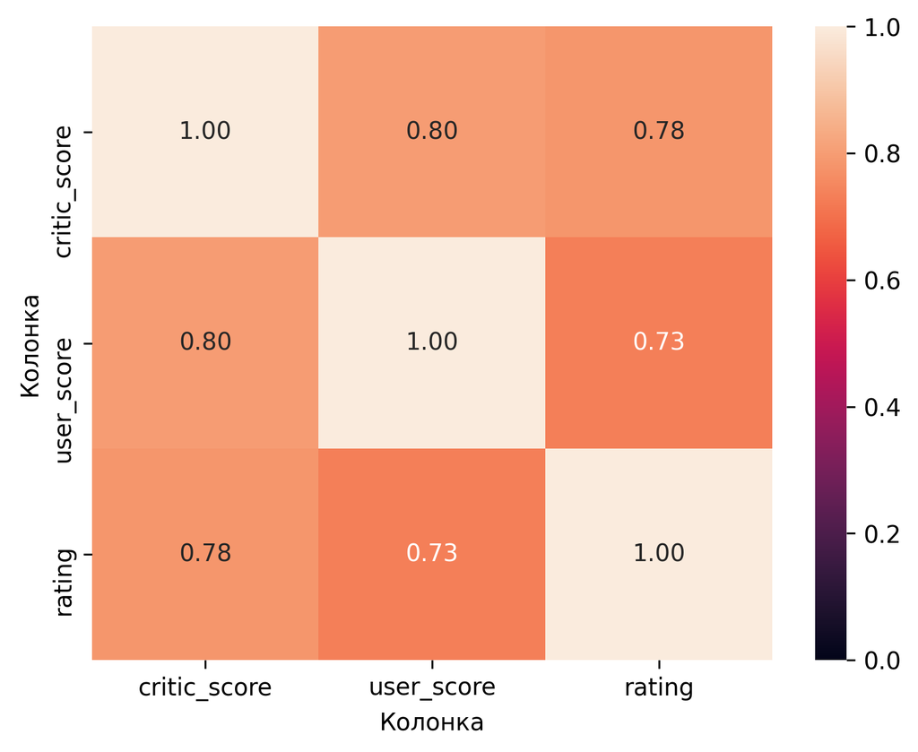

```python
mask = (null_stats['Доля'] >= 0.05)
print("Пропуски в колонках:", null_stats[mask].index.to_list())
display(null_stats[mask].style.format("{:.2%}", subset=["Доля"]))
display(df[df[null_stats[mask].index].isna().any(axis=1)].sample(10))
correlation_matrix = df.loc[:, null_stats[mask].index].isna().corr()
sns.heatmap(correlation_matrix, annot=True, fmt=".2f", vmin=0, vmax=1)
```

Обращаем внимание на большую корреляцию в между отсутствием данных между колонками возрастного рейтинга, оценками пользователей и критиков.

**Колонки `rating`**

Рассмотрим подробнее данные возрастного рейтинга. Т.к. стандарт **ESRB** действует с **1994** года, то вполне ожидаемо, что у игр вышедших до этого года не будет рейтинга.

**Нулевые значения в колонке `rating` в зависимости от групп в колонках `year_of_release`, `genre`, `platform` и дециля общих продаж**

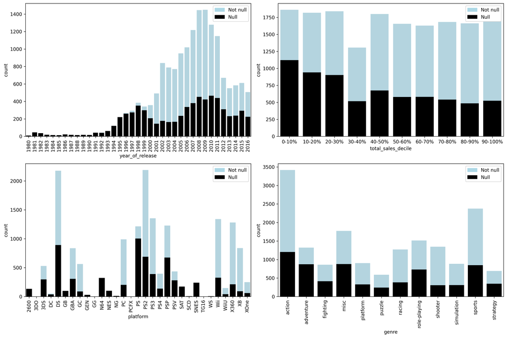

| year_of_release | 1980 | 1981 | 1982 | 1983 | 1984 | 1985 | 1986 | 1987 | 1988 | 1989 | 1990 | 1991 | 1992 | 1993 | 1994 | 1995 | 1996 | 1997 | 1998 | 1999 | 2000 | 2001 | 2002 | 2003 | 2004 | 2005 | 2006 | 2007 | 2008 | … |
| --- | --- | --- | --- | --- | --- | --- | --- | --- | --- | --- | --- | --- | --- | --- | --- | --- | --- | --- | --- | --- | --- | --- | --- | --- | --- | --- | --- | --- | --- | --- |
| null_count | 9 | 46 | 37 | 18 | 14 | 13 | 22 | 17 | 14 | 17 | 16 | 42 | 41 | 62 | 120 | 220 | 260 | 274 | 352 | 298 | 207 | 145 | 177 | 165 | 167 | 235 | 336 | 381 | 452 | … |
| overall_count | 9 | 46 | 37 | 18 | 14 | 14 | 22 | 17 | 15 | 17 | 16 | 42 | 43 | 62 | 121 | 220 | 267 | 293 | 384 | 341 | 357 | 491 | 839 | 789 | 771 | 950 | 1020 | 1218 | 1445 | … |
| fraction | 100.00% | 100.00% | 100.00% | 100.00% | 100.00% | 92.86% | 100.00% | 100.00% | 93.33% | 100.00% | 100.00% | 100.00% | 95.35% | 100.00% | 99.17% | 100.00% | 97.38% | 93.52% | 91.67% | 87.39% | 57.98% | 29.53% | 21.10% | 20.91% | 21.66% | 24.74% | 32.94% | 31.28% | 31.28% | … |

| total_sales_decile | 0-10% | 10-20% | 20-30% | 30-40% | 40-50% | 50-60% | 60-70% | 70-80% | 80-90% | 90-100% |
| --- | --- | --- | --- | --- | --- | --- | --- | --- | --- | --- |
| null_count | 1122 | 942 | 902 | 517 | 675 | 580 | 582 | 541 | 486 | 524 |
| overall_count | 1863 | 1818 | 1841 | 1307 | 1801 | 1657 | 1630 | 1683 | 1663 | 1693 |
| fraction | 60.23% | 51.82% | 49.00% | 39.56% | 37.48% | 35.00% | 35.71% | 32.14% | 29.22% | 30.95% |

| platform | 2600 | 3DO | 3DS | DC | DS | GB | GBA | GC | GEN | GG | N64 | NES | NG | PC | PCFX | PS | PS2 | PS3 | PS4 | PSP | PSV | SAT | SCD | SNES | TG16 | WS | Wii | WiiU | X360 | … |
| --- | --- | --- | --- | --- | --- | --- | --- | --- | --- | --- | --- | --- | --- | --- | --- | --- | --- | --- | --- | --- | --- | --- | --- | --- | --- | --- | --- | --- | --- | --- |
| null_count | 135 | 3 | 298 | 38 | 892 | 98 | 308 | 89 | 29 | 1 | 323 | 100 | 12 | 203 | 1 | 1004 | 689 | 389 | 139 | 676 | 281 | 174 | 6 | 241 | 2 | 6 | 326 | 42 | 213 | … |
| overall_count | 135 | 3 | 530 | 52 | 2177 | 98 | 837 | 563 | 29 | 1 | 323 | 100 | 12 | 990 | 1 | 1215 | 2189 | 1355 | 395 | 1229 | 435 | 174 | 6 | 241 | 2 | 6 | 1340 | 147 | 1281 | … |
| fraction | 100.00% | 100.00% | 56.23% | 73.08% | 40.97% | 100.00% | 36.80% | 15.81% | 100.00% | 100.00% | 100.00% | 100.00% | 100.00% | 20.51% | 100.00% | 82.63% | 31.48% | 28.71% | 35.19% | 55.00% | 64.60% | 100.00% | 100.00% | 100.00% | 100.00% | 100.00% | 24.33% | 28.57% | 16.63% | … |

| genre | action | adventure | fighting | misc | platform | puzzle | racing | role-playing | shooter | simulation | sports | strategy |
| --- | --- | --- | --- | --- | --- | --- | --- | --- | --- | --- | --- | --- |
| null_count | 1204 | 872 | 416 | 878 | 328 | 243 | 385 | 732 | 307 | 310 | 847 | 347 |
| overall_count | 3418 | 1323 | 862 | 1772 | 904 | 590 | 1273 | 1516 | 1346 | 884 | 2375 | 691 |
| fraction | 35.23% | 65.91% | 48.26% | 49.55% | 36.28% | 41.19% | 30.24% | 48.28% | 22.81% | 35.07% | 35.66% | 50.22% |

```python
display_markdown(
    "__Нулевые значения в колонке `rating` в зависимости от групп в колонках `year_of_release`, `genre`, `platform` и дециля общих продаж__",
    raw=True,
)

for data in show_nulls_by_groups(df, 'rating'):
    display(
        data.T.style
        .format("{:.0f}")
        .format("{:.2%}", subset=pd.IndexSlice[["fraction"], :])
    )
```

По платформам пропуски распределены неравномерно, что можно связать с датой выхода платформы и устанавливает ли производитель платформы ограничения на выпуск игр на ней без рейтинга. Например, у PlayStation и XBOX есть такое требование для продажи игр в Америках (кроме Бразилии), а для остального мира действуют свои правила.

Вплоть до 1996 года игры с рейтингом **ESRB** практически отсутствуют (**меньше 5%**), но после стабильно растут вплоть до пика в **2003** году - **20.91%**, и далее только падают в относительном выражении, но всё ещё продолжают расти в абсолютных значениях до **2009** года.

В разрезе количества проданных копий мы видим нисходящий тренд от **60.23%** пропусков в 10-ом децеле до **30.95%** в 90-ом децеле - чем лучше продаётся игра, тем вероятнее она имеет рейтинг **ESRB**.

По жанрам пропуски распределены неравномерно, что может быть связано с жанровой "модой" в определённый момент времени.

Частичным объяснением отсутствия данных может быть:

- банальное отсутствие рейтинга, потому что рейтинг не более чем индустриальный стандарт, а не требование закона (в большинстве стран);
- демократизация отрасли разработки игр, благодаря чему небольшие команды могут создавать и выпускать игры с мизерным или нулевым бюджетом - на одном энтузиазме. У таких команд даже минимальная цена получения рейтинга ESRB, **3000$**, может оказаться неподъёмной, и, как следствие, необязательной.

Противоречит этому объяснению политика производителей крупнейших игровых платформ PlayStation и XBOX, у который существуют свои внутренние процедуры и требования к изданию игр для их консолей.

Также обращаем внимание на **общее падение выпуска игр с 2009 года**, что удивительно для растущей и по сей день отрасли. Возможно к нам попали данные о продажах игр только на физических носителях, без данных об онлайн-продажах.

**Колонки `user_score` и `critic_score`**

Т.к. отсутствие оценок пользователей и критиков высоко коррелирует с колонкой рейтинга, то графики должны быть практически идентичны

**Нулевые значения в колонке `user_score` в зависимости от групп в колонках `rating`, `year_of_release`, `genre`, `platform` и дециля общих продаж**

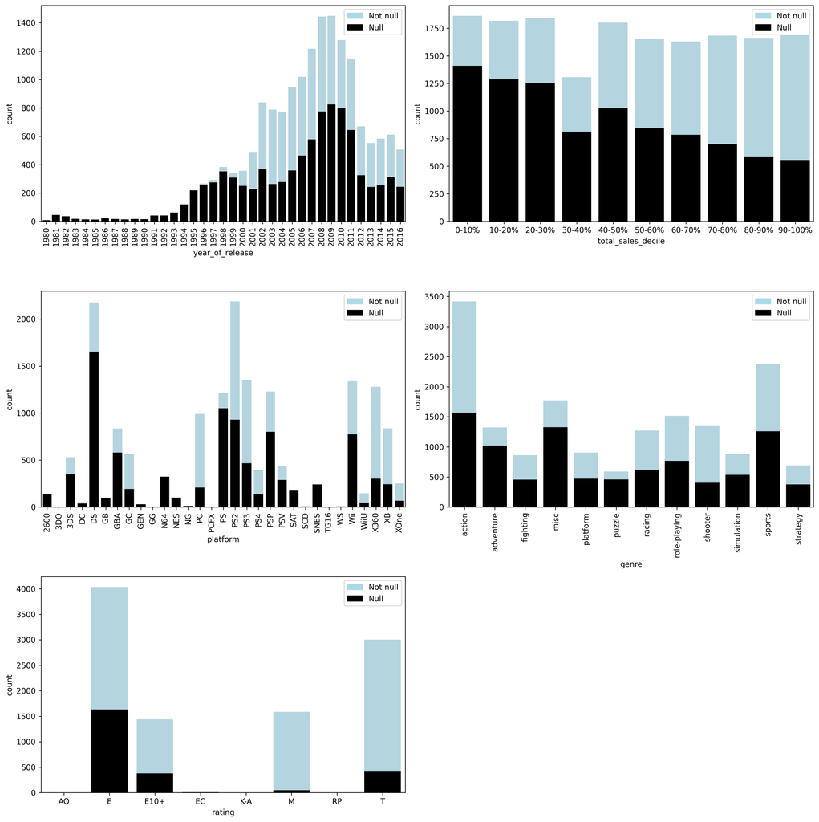

**Нулевые значения в колонке `critic_score` в зависимости от групп в колонках `rating`, `year_of_release`, `genre`, `platform` и дециля общих продаж**

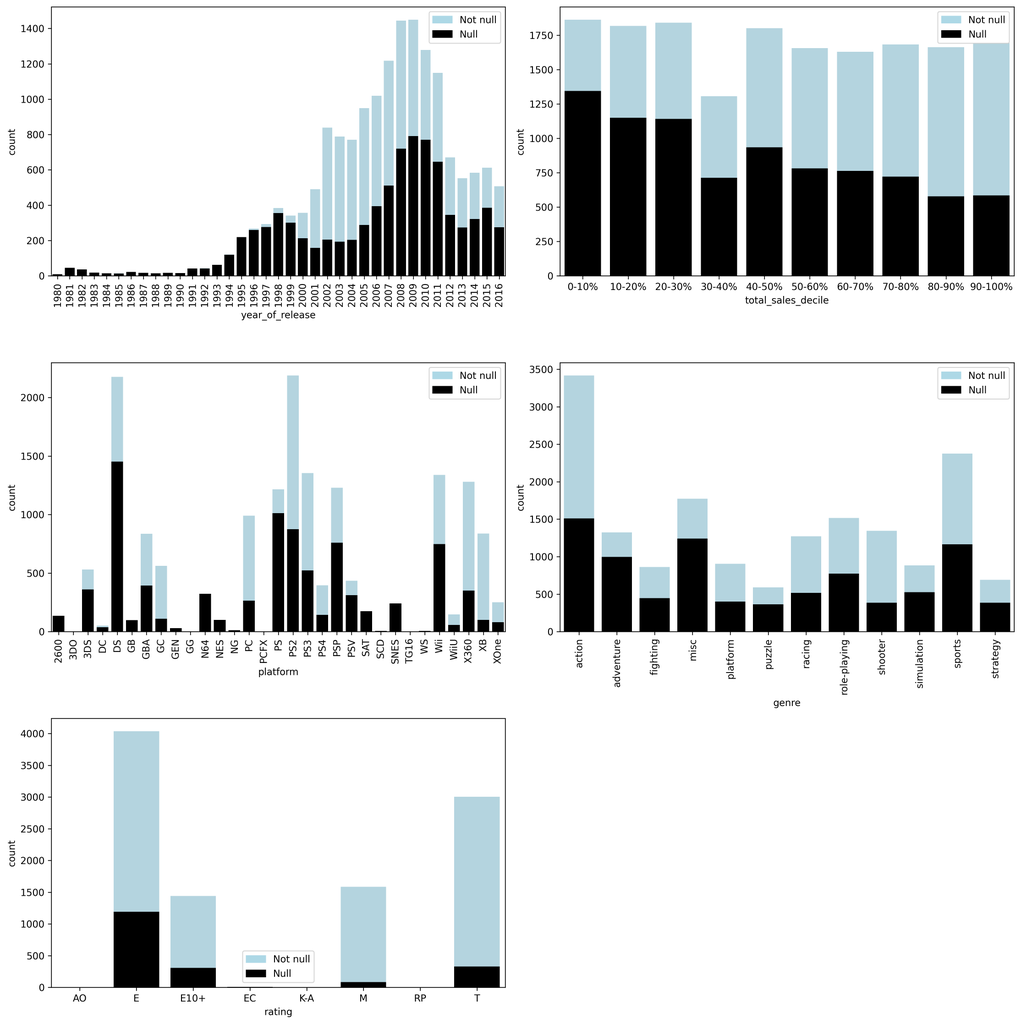

```python
display_markdown(
    "__Нулевые значения в колонке `user_score` в зависимости от групп в колонках `rating`, `year_of_release`, `genre`, `platform` и дециля общих продаж__",
    raw=True,
)
_ = show_nulls_by_groups(df, "user_score")
display_markdown(
    "__Нулевые значения в колонке `critic_score` в зависимости от групп в колонках `rating`, `year_of_release`, `genre`, `platform` и дециля общих продаж__",
    raw=True,
)
_ = show_nulls_by_groups(df, "critic_score")
```

**ВЫВОД**: Мы имеем дело с пропусками **MNAR** - частично мы можем объяснить отсутствие данных, но не полностью. Наличие таких пропусков само по себе может нести полезную информацию для заказчика, поэтому стоит их оставить и изучить подробнее.

#### Обработка

##### Восстановление `eu_sales` и `jp_sales`

```python
df.select_dtypes(np.number).corr().style.format("{:.2f}")
```

|  | na_sales | eu_sales | jp_sales | other_sales | user_score |
| --- | --- | --- | --- | --- | --- |
| na_sales | 1.00 | 0.77 | 0.45 | 0.64 | 0.09 |
| eu_sales | 0.77 | 1.00 | 0.43 | 0.72 | 0.06 |
| jp_sales | 0.45 | 0.43 | 1.00 | 0.29 | 0.13 |
| other_sales | 0.64 | 0.72 | 0.29 | 1.00 | 0.06 |
| user_score | 0.09 | 0.06 | 0.13 | 0.06 | 1.00 |

Есть хорошие шансы восстановить данные о продажах в Европе, она неплохо коррелирует с данные по Северной Америке и прочими продажами, у Японии показатели похуже. Но возможно есть нелинейные зависимости, которые обычной корреляцией не разглядишь.

Попробуем построить ML-модель на основе градиентного бустинга. Сравним её с лининейной регрессией, а за базовую модель примем запрошенную в задании процедуру: заменить пропуски с количеством проданных копий на среднее значение в зависимости от названия платформы и года выхода игры. Учтём также ситуацию, когда не для всех групп мы можем вычислить среднее (отсутствующие значение единственное в группе); для такого случая заполним средним по всей выборке.

```python
# Импорт нужных библиотек
from sklearn.model_selection import train_test_split, cross_validate
from sklearn.pipeline import Pipeline
from sklearn.compose import ColumnTransformer
from sklearn.preprocessing import StandardScaler, OrdinalEncoder
from sklearn.impute import SimpleImputer
from sklearn.experimental import enable_hist_gradient_boosting
from sklearn.ensemble import HistGradientBoostingRegressor
from sklearn.metrics import mean_squared_error, mean_absolute_error, r2_score, median_absolute_error
from sklearn.base import BaseEstimator
```

```python
class MeanByYearPlatformPredictor(BaseEstimator):
    """модель предсказания количества копий на основании среднего в группе ("платформа", "год")"""
    def __init__(self, target):
        self.target = target

    def fit(self, X, y):
        temp = pd.concat([X[['year_of_release','platform']], pd.Series(y).rename(self.target)], axis=1)
        self.means = temp.groupby(['year_of_release', 'platform']).mean().dropna()

        return self

    def predict(self, X):
        data = X[['year_of_release','platform']].copy()

        data = data[['year_of_release','platform']].reset_index().set_index(['year_of_release', 'platform'])
        data = data.join(self.means).reset_index().set_index('index').fillna(self.means.mean())


        return data[[self.target]].loc[X.index]
```

```python
def show_metrics(y_true, y_pred) -> None:
    """простая функция вывода основных метрик для регрессии"""
    mse = mean_squared_error(y_true, y_pred)
    rmse = np.sqrt(mse)
    mean_ae = mean_absolute_error(y_true, y_pred)
    median_ae = median_absolute_error(y_true, y_pred)
    r2 = r2_score(y_true, y_pred)
    print(f"R²: {r2:.4f}, Mean AE: {mean_ae:.4f}, Median AE: {median_ae:.4f}, MSE: {mse:.4f}, RMSE: {rmse:.4f}")
```

Готовим выборку для обучения модели. Используем `Pipeline` для организации манипуляций и гарантии отсутствия утечек данных между тренировочной и тестовой выборками.

```python
from copy import deepcopy

from sklearn.linear_model import Lasso, Ridge
from sklearn.pipeline import make_pipeline
from sklearn.preprocessing import OneHotEncoder

target_columns = ['eu_sales', 'jp_sales']
train, test = train_test_split(df.dropna(subset=target_columns), random_state=27)
# из-за неуловимых глюков при работе с категориальными переменными в этих версиях
# pandas и sklearn, для тренировки модели привожу их целочисленному
train[ordinal_columns] = train[ordinal_columns].astype(pd.Int64Dtype())
test[ordinal_columns] = test[ordinal_columns].astype(pd.Int64Dtype())

def make_pipes(data, target_columns: list[str]):
    # категории беру из всего датасета
    nominal_categories = [df[cat].cat.categories.tolist() + ['empty'] for cat in categorical_columns]
    ordinal_categories = [sorted(df[cat].cat.categories.tolist() + [-1]) for cat in ordinal_columns]

    pipes = dict()

    for target_column in target_columns:
        target_pipes = []
        for estimator in [HistGradientBoostingRegressor(), Ridge()]:
            target_pipes.append(
                Pipeline(
                    steps=[
                        (
                            "column_specific_preprocess",
                            ColumnTransformer(
                                transformers=[
                                    ("drop_unused", "drop", ["name"]),
                                    (
                                        # пропуски в ординальных колонках заполняем `-1`, `OrdinalEncoder`
                                        # в любом случае перекодирует их по своему усмотрению
                                        "ordinal_preprocess",
                                        Pipeline(
                                            steps=[
                                                ("ordinal_impute", SimpleImputer(strategy="constant", fill_value=-1)),
                                                ("ordinal_encode", OrdinalEncoder(categories=ordinal_categories, handle_unknown='use_encoded_value', unknown_value=-1)),
                                            ]
                                        ),
                                        ordinal_columns,
                                    ),
                                    (
                                        # пропуски в номинативных колонках заполняем `empty`
                                        "categorical_preprocess",
                                        Pipeline(
                                            steps=[
                                                ("categorical_impute", SimpleImputer(strategy="constant", fill_value="empty")),
                                                ("categorical_encode", OneHotEncoder(categories=nominal_categories, drop='first', sparse=False)),
                                            ]
                                        ),
                                        categorical_columns,
                                    ),
                                ],
                                remainder="passthrough",
                            ),
                        ),
                        # масштабирование никогда не повредит; стандартизация оставляет возможность для модели обучиться на выбросах
                        ("scaler", StandardScaler()),
                        ("model", estimator),
                    ],
                )
            )

            if str(estimator.__class__).find("linear_model") >= 0:
                # линейные модели не умеют обращаться с пропусками, поэтому заполняем их средним
                float_imputer = (
                    "float_imputer",
                    SimpleImputer(strategy="mean"),
                    ["na_sales", (set(['eu_sales', 'jp_sales']) ^ set([target_column])).pop(), "other_sales", "user_score"],
                )
                target_pipes[-1]['column_specific_preprocess'].transformers.insert(1, float_imputer)

        pipes[target_column] = target_pipes

    return pipes

pipes = make_pipes(df, target_columns)
# отдельно добавим к пайплайнам нашу базовую модель (среднее по группам)
pipes['eu_sales'].append(make_pipeline(MeanByYearPlatformPredictor('eu_sales')))
pipes['jp_sales'].append(make_pipeline(MeanByYearPlatformPredictor('jp_sales')))
```

```python
pipe = pipes['eu_sales'][1][:-1] # пайплайн с OHE без последнего шага - модели
print(f"Число обусловленности датасета после препроцессинга и кодирования: {np.linalg.cond(pipe.fit_transform(train.dropna(subset=['eu_sales']).drop(columns=['eu_sales']))):.2e}")
```

```
Число обусловленности датасета после препроцессинга и кодирования: 3.21e+16
```

Кроссвалидация на тренировочной выборке

| target | model |  | R² | Mean AE | Median AE | MSE | RMSE |
| --- | --- | --- | --- | --- | --- | --- | --- |
| eu_sales | HistGradientBoostingRegressor | mean | 0.7939 | 0.0515 | 0.0119 | 0.0749 | 0.2321 |
|  |  | std | 0.1018 | 0.0083 | 0.0027 | 0.1227 | 0.1528 |
|  | MeanByYearPlatformPredictor | mean | -0.0237 | 0.1933 | 0.1177 | 0.2828 | 0.5017 |
|  |  | std | 0.0197 | 0.0186 | 0.0037 | 0.2643 | 0.1859 |
|  | Ridge | mean | 0.5301 | 0.0976 | 0.0410 | 0.1045 | 0.3065 |
|  |  | std | 0.3650 | 0.0073 | 0.0021 | 0.0787 | 0.1082 |
| jp_sales | HistGradientBoostingRegressor | mean | 0.4733 | 0.0715 | 0.0195 | 0.0509 | 0.2232 |
|  |  | std | 0.1197 | 0.0058 | 0.0015 | 0.0138 | 0.0340 |
|  | MeanByYearPlatformPredictor | mean | -0.0264 | 0.1200 | 0.0687 | 0.1023 | 0.3157 |
|  |  | std | 0.0134 | 0.0079 | 0.0033 | 0.0331 | 0.0540 |
|  | Ridge | mean | 0.3261 | 0.1021 | 0.0495 | 0.0656 | 0.2537 |
|  |  | std | 0.0872 | 0.0057 | 0.0018 | 0.0186 | 0.0368 |

```
array([<AxesSubplot:title={'center':'R²'}, ylabel='target,model'>,
       <AxesSubplot:title={'center':'Mean AE'}, ylabel='target,model'>,
       <AxesSubplot:title={'center':'Median AE'}, ylabel='target,model'>,
       <AxesSubplot:title={'center':'MSE'}, ylabel='target,model'>,
       <AxesSubplot:title={'center':'RMSE'}, ylabel='target,model'>],
      dtype=object)
```

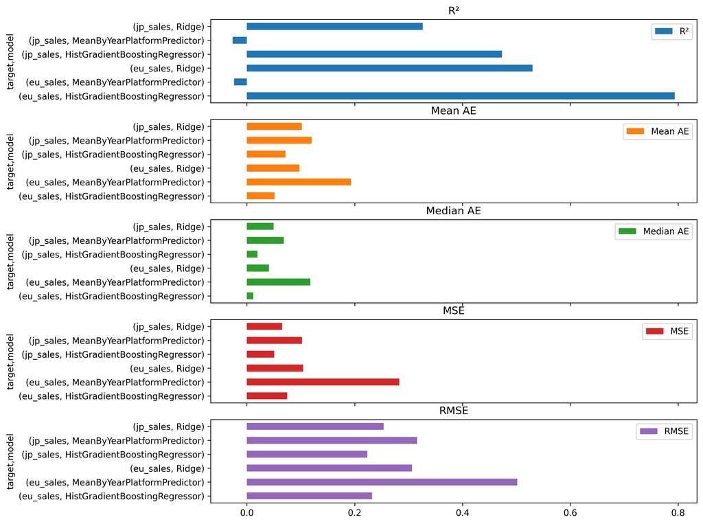

```python
folds = 10
metrics = []

for target_column, target_pipes in pipes.items():
    for pipe in target_pipes:
        X = train.drop(columns=[target_column])
        y = train[[target_column]]

        results = cross_validate(
            pipe, X, y.values.ravel(), cv=folds,
            scoring=['r2', 'neg_median_absolute_error', 'neg_mean_squared_error', 'neg_root_mean_squared_error', 'neg_mean_absolute_error']
        )

        metric = {
            "R²": results['test_r2'],
            "Mean AE": -results['test_neg_mean_absolute_error'],
            "Median AE": -results['test_neg_median_absolute_error'],
            "MSE": -results['test_neg_mean_squared_error'],
            "RMSE": -results['test_neg_root_mean_squared_error']
        }
        estimator_class_name = pipe[-1].__class__.__name__
        # делаем красивый датафрейм с мультииндексом
        index_array = [[target_column] * folds, [estimator_class_name] * folds, range(1, folds + 1)]
        multi_index = pd.MultiIndex.from_arrays(index_array, names=['target', 'model', 'fold'])
        metrics.append(pd.DataFrame(metric, index=multi_index))

stats_df = pd.concat(metrics).groupby(level=['target', 'model']).agg(['mean', 'std']).stack(-1)
display(stats_df.style.format(formatter="{:.4f}"))

stats_df.xs('mean', level=-1).plot(kind='barh', subplots=True, figsize=(10, 10))
```

Для Европы градиентный спуск по всем метрикам лучше линейной модели и замены на среднее в группе: хорошие показатели коэффициента детерминации (модель объясняет > 0.7 всей дисперсии) при низких абсолютных и квадратичных ошибках. Для Японии результат гораздо хуже, всего модель объясняет ~0.45 всей дисперсии при сравнимых размерах ошибок.

Обучим модель градиентного спуска на всей тренировочной выборке и оценим на тестовых данных. Для визуальной оценки построим график истинных/предсказанных значений, а также график остатков.

> **eu_sales**

**Train:**

```
R²: 0.7844, Mean AE: 0.0492, Median AE: 0.0155, MSE: 0.0601, RMSE: 0.2452
```

**Test:**

```
R²: 0.8439, Mean AE: 0.0497, Median AE: 0.0155, MSE: 0.0257, RMSE: 0.1603
```

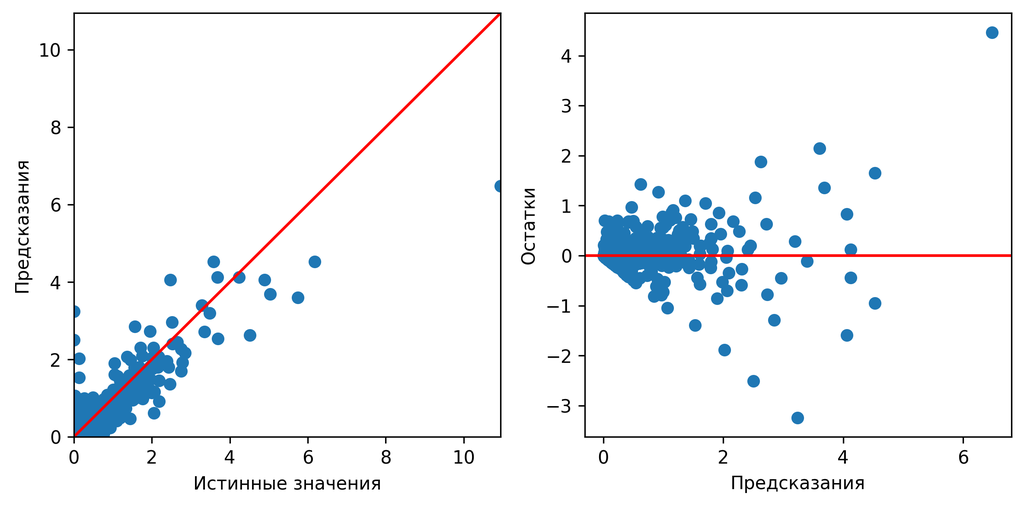

> **jp_sales**

**Train:**

```
R²: 0.7150, Mean AE: 0.0599, Median AE: 0.0169, MSE: 0.0285, RMSE: 0.1688
```

**Test:**

```
R²: 0.4297, Mean AE: 0.0702, Median AE: 0.0174, MSE: 0.0438, RMSE: 0.2094
```

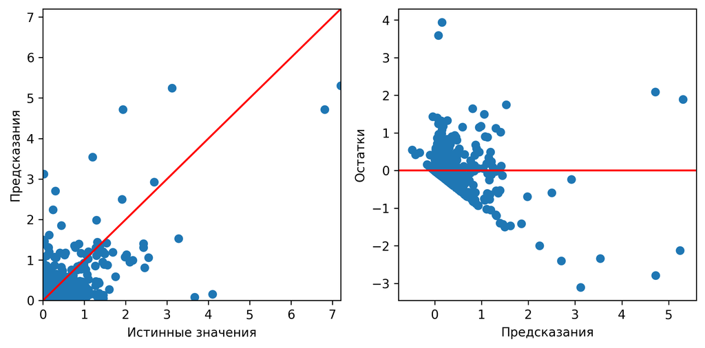

```python
iterator = {'eu_sales': pipes['eu_sales'][0], 'jp_sales': pipes['jp_sales'][0]}
# iterator = {'eu_sales': pipe_boosting_eu, 'jp_sales': pipe_boosting_jp}
for target_column, pipe in iterator.items():
    display_markdown(f"> __{target_column}__", raw=True)

    X_train = train.drop(columns=[target_column])
    X_test = test.drop(columns=[target_column])

    y_train = train[[target_column]]
    y_test = test[[target_column]]

    pipe.fit(X_train, y_train.values.ravel())
    y_pred = pipe.predict(X_test)

    display_markdown("__Train:__", raw=True)
    show_metrics(y_train, pipe.predict(X_train))
    display_markdown("__Test:__", raw=True)
    show_metrics(y_test, y_pred)

    fig, (ax1, ax2) = plt.subplots(nrows=1, ncols=2)
    fig.set_size_inches(8,4)

    # График истинных vs предсказанных значений
    y_max = y_test.max().item()
    y_min = y_test.min().item()

    ax1.plot([y_min, y_max], [y_min, y_max], color='red') # идеальные предсказания
    ax1.scatter(y_test, y_pred)
    ax1.set(xlabel="Истинные значения", ylabel="Предсказания")
    # одинаковый масштаб по x и y
    ax1.set(xlim=(0, max([y_max, y_pred.max()])), ylim=(0, max([y_max, y_pred.max()])))

    # График остатков
    residuals = y_test.values.reshape(-1) - y_pred
    ax2.scatter(y_pred, residuals)
    ax2.axhline(y=0, color='red')
    ax2.set(xlabel="Предсказания", ylabel="Остатки")

    fig.tight_layout()
    plt.show()
```

**ВЫВОД**: для продаж в Европе с ростом истинных значений продаж растёт и дисперсия в предсказаниях, но в целом предсказания концентрируются вокруг линии идеальных предсказаний, а остатки - в районе нуля. Для Японии модель оставляет желать лучшего, но её использование лучше чем простая замена медианой или вообще удаление данных. Принимаю решение использовать обе модели для замены отсутствующих значений в колонках `eu_sales` и `jp_sales`

```python
for target_column, pipe in iterator.items():
    null_records = df[df[target_column].isna()]
    df.loc[df[target_column].isna(), target_column] = pipe.predict(null_records.drop(columns=[target_column]))
    display(df.loc[null_records.index])
```

|  | name | platform | year_of_release | genre | na_sales | eu_sales | jp_sales | other_sales | critic_score | user_score | rating |
| --- | --- | --- | --- | --- | --- | --- | --- | --- | --- | --- | --- |
| 446 | Rhythm Heaven | DS | 2008 | misc | 0.55 | 0.506324 | 1.93 | 0.13 | 83 | 9.0 | E |
| 802 | Dead Rising | X360 | 2006 | action | 1.16 | 0.626107 | 0.08 | 0.20 | 85 | 7.6 | M |
| 1131 | Prince of Persia: Warrior Within | PS2 | 2004 | action | 0.54 | 0.609195 | 0.00 | 0.22 | 83 | 8.5 | M |
| 1132 | Far Cry 4 | XOne | 2014 | shooter | 0.80 | 0.437641 | 0.01 | 0.14 | 82 | 7.5 | M |
| 1394 | Sonic Advance 3 | GBA | 2004 | platform | 0.74 | 0.206673 | 0.08 | 0.06 | 79 | 8.4 | E |
| 1612 | Ratatouille | DS | 2007 | action | 0.49 | 0.561732 | 0.00 | 0.14 | NaN | NaN | NaN |

|  | name | platform | year_of_release | genre | na_sales | eu_sales | jp_sales | other_sales | critic_score | user_score | rating |
| --- | --- | --- | --- | --- | --- | --- | --- | --- | --- | --- | --- |
| 467 | Saints Row 2 | X360 | 2008 | action | 1.94 | 0.79 | -0.023810 | 0.28 | 81 | 8.1 | M |
| 819 | UFC 2009 Undisputed | X360 | 2009 | fighting | 1.48 | 0.39 | 0.032466 | 0.19 | 83 | 7.9 | T |
| 1379 | Hello Kitty Party | DS | 2007 | misc | 0.78 | 0.51 | 0.029963 | 0.12 | NaN | NaN | E |
| 4732 | Castlevania: The Dracula X Chronicles | PSP | 2007 | platform | 0.22 | 0.09 | 0.017507 | 0.07 | 80 | 7.8 | T |

##### Загрузка данных о годах

Пропуски в годах можно восстановить обогатив данные из сторонних источников. Для этого воспользуемся открытым API портала https://www.giantbomb.com

```python
from http import HTTPStatus

from requests.sessions import Session
from requests.exceptions import HTTPError

import time

RETRY_CODES = [
    HTTPStatus.TOO_MANY_REQUESTS,
    HTTPStatus.INTERNAL_SERVER_ERROR,
    HTTPStatus.BAD_GATEWAY,
    HTTPStatus.SERVICE_UNAVAILABLE,
    HTTPStatus.GATEWAY_TIMEOUT,
    420
]
API_KEY = "987b56322fb94180f401ac92d884a7d9e8d9e8ba"
# API_KEY = "<NA>"

def send_request(session, url, headers={}, params={}, timeouts=[0, 10, 60, 300, 3600]):
    for timeout in timeouts:
        time.sleep(timeout)
        try:
            response = session.get(url, headers=headers, params=params)
            response.raise_for_status()

            break

        except HTTPError as exc:
            print(exc)
            code = exc.response.status_code

            if code in RETRY_CODES:
                continue

            raise

    return response
```

```python
headers = {
    "Content-Type": r"application/json; charset=utf-8",
    "Cache-Control": "no-cache",
    "User-Agent": "cv.kov.app/0.1 (vk@kov.app)",
}
```

**Названия платформ**

Загрузим данные о платформах, чтобы при анализе можно было оперировать их названиями, а не аббревиатурами.

```python
def query_platforms():
    with Session() as s:
        results = []
        s.headers.update(headers)
        url = "https://www.giantbomb.com/api/platforms/"
        offset = 0
        while True:
            params = {
                "api_key": API_KEY,
                "format": "json",
                "field_list": "id,abbreviation,name,release_date",
                "offset": offset,
            }
            result = send_request(s, url, params=params)
            results.append(result.json())
            if results[-1]["number_of_total_results"] <= int(offset + results[-1]["limit"]):
                break
            offset += results[-1]["limit"]

    platforms =  pd.concat(
        [pd.DataFrame(result["results"]) for result in results]
    ).set_index("id")
    platforms['release_date'] = platforms['release_date'].astype('datetime64[s]')

    return platforms
```

```python
# # чтобы не нагружать API, мы выгрузили данные о платформах функцией `query_platforms`
# # в `CSV` файл и разместили его в облаке
# platforms = query_platforms()
# platforms.to_csv("./platforms_giantbomb.csv")

platforms = pd.read_csv(
    "https://storage.yandexcloud.net/kobalt-s3-public/share/datasets/yandex-dap/platforms_giantbomb.csv",
    # "./platforms_giantbomb.csv",
    index_col='id',
    parse_dates=["release_date"],
)
```

Посмотрим на загруженные данные

```python
print("Уникальных категорий:", len(platforms["abbreviation"].unique()))
print("\n10 случайных значений:")
platforms.sample(10)
```

```
Уникальных категорий: 194

10 случайных значений:
```

| id | abbreviation | name | release_date |
| --- | --- | --- | --- |
| 87 | WSHP | Wii Shop | 2006-11-30 |
| 57 | GBC | Game Boy Color | 1998-10-31 |
| 63 | TRS8 | TRS-80 | 1980-10-01 |
| 154 | OUYA | Ouya | 2013-06-25 |
| 8 | SMS | Sega Master System | 1985-10-20 |
| 166 | GMT | Gamate | 1990-12-31 |
| 90 | MVIS | Microvision | 1979-11-05 |
| 107 | HALC | RDI Halcyon | 1984-12-31 |
| 182 | EPOC | Epoch Game Pocket Computer | 1984-04-01 |
| 160 | SMC7 | Sony SMC-777 | 1982-12-31 |

Проверим, что все аббревиатуры из нашего датасета соответствуют загруженным данным

```python
print("Не найдены аббревиатуры:")
platforms_mismatch = set(df.platform.unique()).difference(set(platforms['abbreviation'].unique()))
platforms_mismatch
```

```
Не найдены аббревиатуры:
```

```
{'GC', 'NG', 'PS', 'PSV', 'WS', 'XB', 'XOne'}
```

Всего семь значений не найдено. Возможно получится сопоставить данные вручную.

```python
platforms[platforms['abbreviation'].str.contains(('|').join(platforms_mismatch))].sort_values('abbreviation')
```

| id | abbreviation | name | release_date |
| --- | --- | --- | --- |
| 23 | GCN | GameCube | 2001-09-14 |
| 77 | GCOM | Game.Com | 1997-09-30 |
| 59 | NGCD | Neo Geo CD | 1994-10-31 |
| 34 | NGE | N-Gage | 2003-10-07 |
| 80 | NGP | Neo Geo Pocket | 1998-10-28 |
| 81 | NGPC | Neo Geo Pocket Color | 1999-03-16 |
| 211 | NGX | Next Generation Xbox | 2026-07-01 |
| 22 | PS1 | PlayStation | 1994-12-03 |
| 19 | PS2 | PlayStation 2 | 2000-03-04 |
| 35 | PS3 | PlayStation 3 | 2006-11-11 |
| 88 | PS3N | PlayStation Network (PS3) | 2006-11-01 |
| 146 | PS4 | PlayStation 4 | 2013-11-15 |
| 176 | PS5 | PlayStation 5 | 2020-11-12 |
| 143 | PSNV | PlayStation Network (Vita) | 2012-02-12 |
| 18 | PSP | PlayStation Portable | 2005-03-24 |
| 116 | PSPN | PlayStation Network (PSP) | 2008-10-21 |
| 53 | TGCD | TurboGrafx-CD | 1988-12-04 |
| 54 | WSC | WonderSwan Color | 2000-12-09 |
| 87 | WSHP | Wii Shop | 2006-11-30 |
| 65 | WSW | WonderSwan | 1999-03-01 |
| 86 | XBGS | Xbox 360 Games Store | 2005-11-30 |
| 32 | XBOX | Xbox | 2001-11-30 |

Однозначно можно сопоставить названия для 'GC' - GameCube, 'PS' - PlayStation, 'PSV' - PlayStation Network (Vita), 'WS' - WonderSwan, 'XB' - Xbox.

'NG' - очевидно Neo Geo, 'XOne' - 'Xbox One', но по аббревиатуре найти их не получилось, попробуем по имени.

```python
platforms[platforms['name'].str.contains(r'Neo Geo|Xbox One')]
```

| id | abbreviation | name | release_date |
| --- | --- | --- | --- |
| 25 | NEO | Neo Geo | 1990-01-31 |
| 59 | NGCD | Neo Geo CD | 1994-10-31 |
| 80 | NGP | Neo Geo Pocket | 1998-10-28 |
| 81 | NGPC | Neo Geo Pocket Color | 1999-03-16 |
| 145 | XONE | Xbox One | 2013-11-22 |

Заменим аббревиатуры в списке платформ на данные из нашего датасета.

```python
replace_abbr = {
    "GCN": "GC",
    "NEO": "NG",
    "PS1": "PS",
    "PSNV": "PSV",
    "WSW": "WS",
    "XBOX": "XB",
    "XONE": "XOne",
}
platforms = platforms.replace({'abbreviation': replace_abbr})

assert set(df.platform.unique()).difference(set(platforms['abbreviation'].unique())) == set(), "В датасете всё ещё остались аббревиатуры, которых нет в таблице платформ"
```

**Загрузка года издания игр**

Подготовим список игр без года. Нам также понадобится ID платформы для фильтрации результатов поиска.

```python
# сохраняем индекс (теряется при `merge`)
df_null_year = df[df['year_of_release'].isna()].reset_index()
# добавляем данные о платформах (id платформ понадобится при обращении к API)
df_null_year = df_null_year.merge(platforms.reset_index().add_prefix('platform_'), left_on='platform', right_on='platform_abbreviation', how='left')
# восстанавливаем индекс; удаляем возможные дубликаты по названию и платформе; удаляем лишнюю колонку
df_null_year = df_null_year.set_index('index').drop_duplicates(subset=['name', 'platform']).drop(columns=['platform_abbreviation'])
df_null_year.platform_id = df_null_year.platform_id.astype(pd.Int64Dtype())
print("Уникальных записей:", len(df_null_year))
print("Дубликатов по названию и платформе:", df_null_year.duplicated(subset=['name', 'platform'], keep=False).sum())
print("\nСлучайные пять строк:")
display(df_null_year.sample(5))
df_null_year.info()
```

```
Уникальных записей: 269
Дубликатов по названию и платформе: 0

Случайные пять строк:
```

| index | name | platform | year_of_release | genre | na_sales | eu_sales | jp_sales | other_sales | critic_score | user_score | rating | platform_id | platform_name | platform_release_date |
| --- | --- | --- | --- | --- | --- | --- | --- | --- | --- | --- | --- | --- | --- | --- |
| 8437 | James Cameron's Dark Angel | PS2 | NaN | action | 0.08 | 0.07 | 0.00 | 0.02 | 48 | 6.5 | T | 19 | PlayStation 2 | 2000-03-04 |
| 4252 | Tiger Woods PGA Tour 07 | Wii | NaN | sports | 0.43 | 0.00 | 0.00 | 0.04 | 71 | 6.9 | E | 36 | Wii | 2006-11-19 |
| 3257 | Metal Gear Solid 2: Substance | XB | NaN | action | 0.38 | 0.22 | 0.00 | 0.03 | 87 | 8.5 | M | 32 | Xbox | 2001-11-30 |
| 9344 | Bejeweled 3 | X360 | NaN | puzzle | 0.13 | 0.00 | 0.00 | 0.01 | 78 | 8.4 | E | 20 | Xbox 360 | 2005-11-22 |
| 4041 | Wet | X360 | NaN | shooter | 0.23 | 0.21 | 0.01 | 0.05 | 69 | 7.3 | M | 20 | Xbox 360 | 2005-11-22 |

```
<class 'pandas.core.frame.DataFrame'>
Int64Index: 269 entries, 183 to 16760
Data columns (total 14 columns):
 #   Column                 Non-Null Count  Dtype
---  ------                 --------------  -----
 0   name                   269 non-null    object
 1   platform               269 non-null    object
 2   year_of_release        0 non-null      category
 3   genre                  269 non-null    category
 4   na_sales               269 non-null    float32
 5   eu_sales               269 non-null    float32
 6   jp_sales               269 non-null    float32
 7   other_sales            269 non-null    float32
 8   critic_score           154 non-null    category
 9   user_score             127 non-null    float32
 10  rating                 181 non-null    category
 11  platform_id            269 non-null    Int64
 12  platform_name          269 non-null    object
 13  platform_release_date  269 non-null    datetime64[ns]
dtypes: Int64(1), category(4), datetime64[ns](1), float32(5), object(3)
memory usage: 20.2+ KB
```

Подготовим функцию обработки полученных данных о поиске игр через API

```python
def games_with_platform_from_json(json):
    # загружаем в датафрейм, устанавливаем в качестве индекса ID игр на GiantBomb
    games = pd.DataFrame(json['results']).set_index('id')
    # для каждой игры API передаёт массив платформ (словарь), на которых она издавалась;
    # для каждого элемента массива мы делаем отдельную строку в датасете (`explode`)
    # с сохранением прочих данных об играх из строк, из которых этот элемент был взят
    exploded_platforms = games.platforms.explode().dropna()
    # словари с данными о платформах мы "раскладываем" по отдельным колонкам (`json_normalize`)
    # индекс при этом нужно восстановить вручную
    normalized_platforms = pd.json_normalize(exploded_platforms).set_index(exploded_platforms.index).add_prefix('platform_')
    # соединяем всё вместе и избавляемся от ненужных колонок
    drop_columns = ['platforms', 'platform_api_detail_url', 'platform_site_detail_url']
    games = games.join(normalized_platforms).drop(columns=drop_columns)

    return games
```

Загрузка данных игр через API. На вход подаётся название игры из списка игр без года, в ответе содержится массив найденных игр по запросу (до 100 штук), каждая игра в ответе содержит:

- id игры
- её название в базе (может не соответствовать запрошенному)
- список платформ, на которых она выходила
- если есть, дата релиза игры (единая для всех платформ)
- если есть, планируемый год выхода Планируемый год выхода и дата релиза взаимоисключающие - будет заполнено только одно поле в запросе

```python
def query_games(df_null_year):
    with Session() as s:
        s.headers.update(headers)
        url = "https://www.giantbomb.com/api/search/"
        params = {
            "api_key": API_KEY,
            "format": "json",
            "limit": 100,
            "query": "",
            "field_list": "id,name,platforms,expected_release_year,original_release_date",
            "resources": "game"
        }
        search_results = []
        for index, name in df_null_year[['name']].itertuples():
            params['query'] = name
            result = send_request(s, url, params=params)
            if result.json()['number_of_page_results'] != 0:
                search_result = games_with_platform_from_json(json=result.json())
                search_result['index'] = index
                search_results.append(search_result)
            else:
                search_results.append(None)

    return search_results
```

```python
# Из-за ограничений API, не будем к нему общаться в данном ноутбуке, а сохраним результаты в CSV
# pd.concat(query_games(df_null_year)).to_csv("./games_giantbomb.csv", index=False, index_label="index")

# загружаем из CSV
search_results = pd.read_csv(
    "https://storage.yandexcloud.net/kobalt-s3-public/share/datasets/yandex-dap/games_giantbomb.csv",
    dtype={"expected_release_year": pd.Int64Dtype(), "platform_id": pd.Int64Dtype()},
    parse_dates=["original_release_date"],
)
search_results = search_results.replace(
    {"platform_abbreviation": replace_abbr}
).drop_duplicates().set_index('index')
search_results.info()
search_results.sample(10)
```

```
<class 'pandas.core.frame.DataFrame'>
Int64Index: 55937 entries, 183 to 16760
Data columns (total 7 columns):
 #   Column                 Non-Null Count  Dtype
---  ------                 --------------  -----
 0   expected_release_year  5951 non-null   Int64
 1   name                   55937 non-null  object
 2   original_release_date  47425 non-null  datetime64[ns]
 3   resource_type          55937 non-null  object
 4   platform_id            54928 non-null  Int64
 5   platform_name          54928 non-null  object
 6   platform_abbreviation  54928 non-null  object
dtypes: Int64(2), datetime64[ns](1), object(4)
memory usage: 3.5+ MB
```

| index | expected_release_year | name | original_release_date | resource_type | platform_id | platform_name | platform_abbreviation |
| --- | --- | --- | --- | --- | --- | --- | --- |
| 16415 | <NA> | Dakar Desert Rally | 2022-10-04 | game | 176 | PlayStation 5 | PS5 |
| 14298 | <NA> | Minute of Islands | 2021-06-13 | game | 146 | PlayStation 4 | PS4 |
| 12121 | <NA> | Coming Out On Top | 2014-12-10 | game | 94 | PC | PC |
| 10014 | <NA> | Unison League | 2015-05-16 | game | 123 | Android | ANDR |
| 5391 | <NA> | Raiden IV | 2007-06-07 | game | 157 | Nintendo Switch | NSW |
| 15232 | <NA> | Kami no Ue no Mahoutsukai | 2014-12-19 | game | 94 | PC | PC |
| 14887 | <NA> | Funtoon's World | 2015-05-01 | game | 94 | PC | PC |
| 9615 | <NA> | Street Fighter Alpha 2 | 1996-02-27 | game | 84 | Arcade | ARC |
| 11149 | <NA> | Warrior of Chaos | 2020-12-15 | game | 94 | PC | PC |
| 1520 | <NA> | 8Doors: Arum's Afterlife Adventure | 2021-04-07 | game | 179 | Xbox Series X\|S | XSX |

Используем `fuzzywuzzy` для нестрогого поиска по названию. Среди 100 возвращённых API игр ищет среди них наиболее близкое.

```python
def games_fuzzy_search(df_null_year, search_results):
    from fuzzywuzzy.process import extractOne

    matches = []
    for index, name, platform in df_null_year[["name", "platform"]].itertuples():
        try:
            search_result = search_results.loc[index]
            search_result = search_result[search_result["platform_abbreviation"] == platform]

            names_list = search_result.name
            best_match, score, _ = extractOne(query=name, choices=names_list, score_cutoff=60)
            search_result_best_match = search_result[search_result.name == best_match]
            matches.append(
                {
                    "index": index,
                    "name": name,
                    "platform": platform,
                    "best_match": best_match,
                    "score": score,
                    # если найдено больше двух игр с одним названием и платформой
                    # (например, разные игры с одним названием "Tomb Raider" выходили
                    # на PC в 1996 и в 2013 году), то берём данные из первой записи
                    "expected_release_year": search_result_best_match["expected_release_year"].iloc[0],
                    "original_release_date": search_result_best_match["original_release_date"].iloc[0],
                    # считаем кол-во таких дубликатов
                    "number_of_duplicates": search_result_best_match.shape[0]
                }
            )

        except (AttributeError, TypeError, KeyError) as error:
            matches.append(
                {
                    "index": index,
                    "name": name,
                    "platform": platform
                }
            )

    return pd.DataFrame(matches).set_index('index').astype({'expected_release_year': pd.Int64Dtype(), 'number_of_duplicates': pd.Int64Dtype()})
```

```python
df_matches = games_fuzzy_search(df_null_year, search_results)
df_matches.info()
df_matches.sample(10)
```

```
<class 'pandas.core.frame.DataFrame'>
Int64Index: 269 entries, 183 to 16760
Data columns (total 7 columns):
 #   Column                 Non-Null Count  Dtype
---  ------                 --------------  -----
 0   name                   269 non-null    object
 1   platform               269 non-null    object
 2   best_match             261 non-null    object
 3   score                  261 non-null    float64
 4   expected_release_year  23 non-null     Int64
 5   original_release_date  237 non-null    datetime64[ns]
 6   number_of_duplicates   261 non-null    Int64
dtypes: Int64(2), datetime64[ns](1), float64(1), object(3)
memory usage: 17.3+ KB
```

| index | name | platform | best_match | score | expected_release_year | original_release_date | number_of_duplicates |
| --- | --- | --- | --- | --- | --- | --- | --- |
| 4874 | LEGO Harry Potter: Years 5-7 | 3DS | LEGO Harry Potter: Years 5-7 | 100.0 | <NA> | 2011-11-11 | 1 |
| 9896 | Saru! Get You! Million Monkeys | PS2 | Get on Da Mic | 86.0 | <NA> | 2004-10-05 | 1 |
| 14949 | Battle vs. Chess | PC | Battle Chess | 95.0 | 1988 | NaT | 1 |
| 8261 | Twisted Metal: Small Brawl | PS | Twisted Metal Small Brawl | 98.0 | <NA> | 2001-11-26 | 1 |
| 11149 | Demon Chaos | PS2 | Demon Chaos | 100.0 | <NA> | 2007-05-22 | 1 |
| 2802 | WarioWare: Twisted! | GBA | WarioWare Twisted! | 97.0 | <NA> | 2005-05-23 | 1 |
| 3524 | Madden NFL 2002 | XB | Madden NFL 2002 | 100.0 | <NA> | 2001-08-13 | 1 |
| 16392 | Aquaman: Battle for Atlantis | XB | Aquaman: Battle for Atlantis | 100.0 | <NA> | 2003-07-30 | 1 |
| 5696 | Singularity | X360 | Singularity | 100.0 | <NA> | 2010-06-29 | 2 |
| 5561 | Custom Robo | N64 | Custom Robo | 100.0 | <NA> | 1999-12-08 | 1 |

```python
# данные о годе выпуска могут содержаться в двух колонках - 'expected_release_year', 'original_release_date'
# поэтому объединяем в одну используя `where` и удаляем лишние
df_matches['year_predicted'] = df_matches['expected_release_year'].where(df_matches['expected_release_year'].notna(), df_matches['original_release_date'].dt.year)
df_matches = df_matches.drop(columns=['expected_release_year', 'original_release_date'])

print("Дубликатов по названию и платформе:", df_matches.duplicated(subset=['name', 'platform'],keep=False).sum())
print("\nСлучайные десять строк:")
display(df_matches.sample(10))
df_matches.info()
```

```
Дубликатов по названию и платформе: 0

Случайные десять строк:
```

| index | name | platform | best_match | score | number_of_duplicates | year_predicted |
| --- | --- | --- | --- | --- | --- | --- |
| 4689 | NHL Slapshot | Wii | NHL Slapshot | 100.0 | 1 | 2010 |
| 611 | Space Invaders | 2600 | Space Invaders | 100.0 | 1 | 1978 |
| 15509 | Steal Princess | DS | Steal Princess | 100.0 | 1 | 2009 |
| 12087 | Port Royale 3 | PS3 | Port Royale 3: Pirates & Merchants | 90.0 | 1 | 2012 |
| 9796 | Charm Girls Club: My Fashion Mall | DS | Charm Girls Club: My Fashion Mall | 100.0 | 1 | 2009 |
| 2504 | Madden NFL 07 | PSP | Madden NFL 07 | 100.0 | 1 | 2006 |
| 9837 | Record of Agarest War Zero | PS3 | Record of Agarest War Zero | 100.0 | 1 | 2011 |
| 2547 | The Lord of the Rings: War in the North | PS3 | The Lord of the Rings: War in the North | 100.0 | 1 | 2011 |
| 6338 | The Legend of Zelda: The Minish Cap(weekly JP ... | GBA | The Legend of Zelda: The Minish Cap | 95.0 | 1 | 2004 |
| 2189 | Yakuza 4 | PS3 | Yakuza 4 | 100.0 | 1 | 2010 |

```
<class 'pandas.core.frame.DataFrame'>
Int64Index: 269 entries, 183 to 16760
Data columns (total 6 columns):
 #   Column                Non-Null Count  Dtype
---  ------                --------------  -----
 0   name                  269 non-null    object
 1   platform              269 non-null    object
 2   best_match            261 non-null    object
 3   score                 261 non-null    float64
 4   number_of_duplicates  261 non-null    Int64
 5   year_predicted        260 non-null    Int64
dtypes: Int64(2), float64(1), object(3)
memory usage: 15.2+ KB
```

Т.к. API возвращает дату выхода не для каждой платформы в отдельности, а одну для каждой игры, то это можем исказить наши данные. Чтобы частично невилировать эту особенность используемой базы данных, мы присвоим всем найденным играм с датой выхода меньшей, чем год выхода соответствующей платформы, год выхода этой платформы.

```python
df_matches = (
    df_matches.reset_index()
    .merge(
        platforms.add_prefix("platform_"),
        left_on="platform",
        right_on="platform_abbreviation",
    )
    .set_index("index")
)
print("Найденные игры с датой выхода меньшей даты выхода платформы:")
mask = df_matches["year_predicted"] < df_matches["platform_release_date"].dt.year
df_matches[mask]
```

```
Найденные игры с датой выхода меньшей даты выхода платформы:
```

| index | name | platform | best_match | score | number_of_duplicates | year_predicted | platform_abbreviation | platform_name | platform_release_date |
| --- | --- | --- | --- | --- | --- | --- | --- | --- | --- |
| 5359 | Dragon Ball Z: Budokai Tenkaichi 2 (JP sales) | Wii | Dragon Ball Z: Budokai Tenkaichi | 95.0 | 1 | 2005 | Wii | Wii | 2006-11-19 |
| 15291 | Wii de Asobu: Metroid Prime | Wii | Metroid Prime | 90.0 | 1 | 2002 | Wii | Wii | 2006-11-19 |
| 11270 | Super Puzzle Fighter II | GBA | Super Puzzle Fighter II Turbo | 95.0 | 1 | 1996 | GBA | Game Boy Advance | 2001-03-21 |
| 11993 | Smashing Drive | GC | Smashing Drive | 100.0 | 1 | 2000 | GC | GameCube | 2001-09-14 |
| 5951 | Harvest Moon: The Tale of Two Towns | 3DS | Harvest Moon: The Tale of Two Towns | 100.0 | 1 | 2010 | 3DS | Nintendo 3DS | 2011-02-26 |
| 6376 | Disgaea 3: Absence of Detention | PSV | Disgaea 3: Absence of Detention | 100.0 | 1 | 2011 | PSV | PlayStation Network (Vita) | 2012-02-12 |

```python
df_matches.loc[mask, 'year_predicted'] = df_matches[mask]['platform_release_date'].dt.year
print("Проверяем исправление года:")
df_matches[mask]
```

```
Проверяем исправление года:
```

| index | name | platform | best_match | score | number_of_duplicates | year_predicted | platform_abbreviation | platform_name | platform_release_date |
| --- | --- | --- | --- | --- | --- | --- | --- | --- | --- |
| 5359 | Dragon Ball Z: Budokai Tenkaichi 2 (JP sales) | Wii | Dragon Ball Z: Budokai Tenkaichi | 95.0 | 1 | 2006 | Wii | Wii | 2006-11-19 |
| 15291 | Wii de Asobu: Metroid Prime | Wii | Metroid Prime | 90.0 | 1 | 2006 | Wii | Wii | 2006-11-19 |
| 11270 | Super Puzzle Fighter II | GBA | Super Puzzle Fighter II Turbo | 95.0 | 1 | 2001 | GBA | Game Boy Advance | 2001-03-21 |
| 11993 | Smashing Drive | GC | Smashing Drive | 100.0 | 1 | 2001 | GC | GameCube | 2001-09-14 |
| 5951 | Harvest Moon: The Tale of Two Towns | 3DS | Harvest Moon: The Tale of Two Towns | 100.0 | 1 | 2011 | 3DS | Nintendo 3DS | 2011-02-26 |
| 6376 | Disgaea 3: Absence of Detention | PSV | Disgaea 3: Absence of Detention | 100.0 | 1 | 2012 | PSV | PlayStation Network (Vita) | 2012-02-12 |

Во время поиска были найдены игры с одинаковым названием и платформой, но выходящие в разные года. Это либо переиздания игры с улучшенной графикой/механиками, либо совсем другой продукт. В любом случае, корректно считать такие игры отдельными продуктами, а не вариантом одной и той же игры. Проверим такие игры и решим, что с ними делать.

```python
# - среди всех найденных игр находим игры у которых больше одной уникальной записи по наименованию и платформе
# - выводим данные о названии игры в базе GiantBomb, поисковом запросе (название игры в нашем датасете), дате выхода
#   выхода игры по базе GiantBomb, предсказанном нами годе выхода и платформе
pd.merge(
    search_results.drop_duplicates(),
    df_matches[df_matches["number_of_duplicates"] != 1],
    left_on=["name", "platform_abbreviation"],
    right_on=["best_match", "platform"],
).filter(
    [
        "name_y",
        "best_match",
        "original_release_date",
        "year_predicted",
        "platform_abbreviation_x",
    ]
)
```

|  | name_y | best_match | original_release_date | year_predicted | platform_abbreviation_x |
| --- | --- | --- | --- | --- | --- |
| 0 | Tomb Raider (2013) | Tomb Raider | 1996-11-14 | 1996 | PC |
| 1 | Tomb Raider (2013) | Tomb Raider | 2013-03-05 | 1996 | PC |
| 2 | Singularity | Singularity | 2010-06-29 | 2010 | X360 |
| 3 | Singularity | Singularity | 2010-04-30 | 2010 | X360 |
| 4 | GRID | GRID | 2008-06-03 | 2008 | PC |
| 5 | GRID | GRID | 2019-10-11 | 2008 | PC |

В нашей базе игра **Tomb Rider** 2013 года выпуска имеет уникальное наименование путём добавления к нему года выхода в скобках. База **GiantBomb** не устанавливает такого ограничения по наименованию (требование уникальности).

Игры с одинаковым названием **Singularity** выходили на **Xbox 360** в одном и том же году, но в разных жанрах (шутер и аркада). Игры выходили в одном году, поэтому это не повлияет на наши данные.

Исправим год игры **Tomb Rider** и **GRID**.

```python
df_matches.loc[(df_matches['name'] == 'Tomb Raider (2013)') & (df_matches['platform_abbreviation'] == "PC"), 'year_predicted'] = 2013
df_matches.loc[(df_matches['name'] == 'GRID') & (df_matches['platform_abbreviation'] == "PC"), 'year_predicted'] = 2009
df_matches.loc[df_matches['name'].str.contains(r'GRID|Tomb Raider \(2013\)') & (df_matches['platform_abbreviation'] == "PC")]
```

| index | name | platform | best_match | score | number_of_duplicates | year_predicted | platform_abbreviation | platform_name | platform_release_date |
| --- | --- | --- | --- | --- | --- | --- | --- | --- | --- |
| 5401 | Tomb Raider (2013) | PC | Tomb Raider | 90.0 | 2 | 2013 | PC | PC | 1981-08-12 |
| 13970 | GRID | PC | GRID | 100.0 | 2 | 2009 | PC | PC | 1981-08-12 |

Каждому найденному наименованию `fuzzywuzzy` дала свою оценку в баллах от 0 до 100, где 100 - полностью идентичная строка. Вручную проверим значения, которые меньше 100 или вообще не были найдены.

```python
print("Количество:", df_matches[df_matches['score'] != 100].sort_values('score').shape[0])
df_matches[df_matches['score'] != 100].sort_values('score')
```

```
Количество: 62
```

| index | name | platform | best_match | score | number_of_duplicates | year_predicted | platform_abbreviation | platform_name | platform_release_date |
| --- | --- | --- | --- | --- | --- | --- | --- | --- | --- |
| 16695 | Hakuouki: Shinsengumi Kitan | PS3 | Hakuoki: Stories of the Shinsengumi | 69.0 | 1 | 2010 | PS3 | PlayStation 3 | 2006-11-11 |
| 16251 | Dream Dancer | DS | Dream Salon | 70.0 | 1 | 2009 | DS | Nintendo DS | 2004-11-21 |
| 16528 | AKB1/48: Idol to Guam de Koishitara... | X360 | de Blob 2 | 86.0 | 1 | 2011 | X360 | Xbox 360 | 2005-11-22 |
| 16565 | Brothers in Arms: Furious 4 | X360 | Enchanted Arms | 86.0 | 1 | 2006 | X360 | Xbox 360 | 2005-11-22 |
| 13470 | Reader Rabbit 2nd Grade | Wii | Phineas and Ferb: Across the 2nd Dimension | 86.0 | 1 | 2011 | Wii | Wii | 2006-11-19 |
| 16584 | Agarest Senki: Re-appearance | PS3 | Angel Senki | 86.0 | 1 | 2009 | PS3 | PlayStation 3 | 2006-11-11 |
| 15232 | Umineko no Naku Koro ni San: Shinjitsu to Gens... | PS3 | Ni no Kuni: Wrath of the White Witch | 86.0 | 1 | 2011 | PS3 | PlayStation 3 | 2006-11-11 |
| 14567 | Majesty 2: The Fantasy Kingdom Sim | X360 | Final Fantasy XIII-2 | 86.0 | 1 | 2011 | X360 | Xbox 360 | 2005-11-22 |
| 12909 | Mobile Ops: The One Year War | X360 | Spec Ops: The Line | 86.0 | 1 | 2012 | X360 | Xbox 360 | 2005-11-22 |
| 11950 | Mega Man Battle Network: Operation Shooting Star | DS | Mega Man Star Force | 86.0 | 1 | 2006 | DS | Nintendo DS | 2004-11-21 |
| 14799 | Samurai Spirits: Tenkaichi Kenkakuden | PS2 | Samurai Western | 86.0 | 1 | 2005 | PS2 | PlayStation 2 | 2000-03-04 |
| 9896 | Saru! Get You! Million Monkeys | PS2 | Get on Da Mic | 86.0 | 1 | 2004 | PS2 | PlayStation 2 | 2000-03-04 |
| 15928 | Writing and Speaking Beautiful Japanese DS | DS | Tetris DS | 86.0 | 1 | 2006 | DS | Nintendo DS | 2004-11-21 |
| 7049 | Jet X20 | PS2 | Kawasaki Jet Ski | 86.0 | 1 | 2007 | PS2 | PlayStation 2 | 2000-03-04 |
| 16021 | Shonen Jump's Yu-Gi-Oh! GX Card Almanac | DS | Yu-Gi-Oh! 5D's Stardust Accelerator: World Cha... | 86.0 | 1 | 2009 | DS | Nintendo DS | 2004-11-21 |
| 5401 | Tomb Raider (2013) | PC | Tomb Raider | 90.0 | 2 | 2013 | PC | PC | 1981-08-12 |
| 7490 | Valkyria Chronicles III: Unrecorded Chronicles | PSP | Valkyria Chronicles II | 90.0 | 1 | 2010 | PSP | PlayStation Portable | 2005-03-24 |
| 6723 | Jonah Lomu Rugby Challenge | PS3 | Rugby Challenge | 90.0 | 1 | 2011 | PS3 | PlayStation 3 | 2006-11-11 |
| 8803 | Jurassic Park: The Game | X360 | Jurassic Park | 90.0 | 1 | 2011 | X360 | Xbox 360 | 2005-11-22 |
| 12087 | Port Royale 3 | PS3 | Port Royale 3: Pirates & Merchants | 90.0 | 1 | 2012 | PS3 | PlayStation 3 | 2006-11-11 |
| 15291 | Wii de Asobu: Metroid Prime | Wii | Metroid Prime | 90.0 | 1 | 2006 | Wii | Wii | 2006-11-19 |
| 12375 | Build-A-Bear Workshop: Friendship Valley | Wii | Build-A-Bear Workshop | 90.0 | 1 | 2010 | Wii | Wii | 2006-11-19 |
| 9245 | Our House Party! | Wii | Our House | 90.0 | 1 | 2009 | Wii | Wii | 2006-11-19 |
| 10910 | Luminous Arc 2 (JP sales) | DS | Luminous Arc | 90.0 | 1 | 2007 | DS | Nintendo DS | 2004-11-21 |
| 12387 | Port Royale 3 | X360 | Port Royale 3: Pirates & Merchants | 90.0 | 1 | 2012 | X360 | Xbox 360 | 2005-11-22 |
| 13499 | Monster Hunter Frontier Online | PS3 | Monster Hunter Frontier G | 91.0 | 1 | 2013 | PS3 | PlayStation 3 | 2006-11-11 |
| 2599 | PES 2009: Pro Evolution Soccer | PSP | Pro Evolution Soccer 2009 | 95.0 | 1 | 2008 | PSP | PlayStation Portable | 2005-03-24 |
| 12741 | Prinny: Can I Really Be The Hero? (US sales) | PSP | Prinny: Can I Really Be the Hero? | 95.0 | 1 | 2009 | PSP | PlayStation Portable | 2005-03-24 |
| 14298 | Half-Minute Hero 2 | PSP | Half-Minute Hero | 95.0 | 1 | 2009 | PSP | PlayStation Portable | 2005-03-24 |
| 15137 | The King of Fighters: Maximum Impact - Maniax | XB | The King of Fighters: Maximum Impact | 95.0 | 1 | 2004 | XB | Xbox | 2001-11-30 |
| 9419 | Disney's Cinderella: Magical Dreams | GBA | Cinderella: Magical Dreams | 95.0 | 1 | 2005 | GBA | Game Boy Advance | 2001-03-21 |
| 15556 | Mario Tennis | 3DS | Mario Tennis Open | 95.0 | 1 | 2012 | 3DS | Nintendo 3DS | 2011-02-26 |
| 11270 | Super Puzzle Fighter II | GBA | Super Puzzle Fighter II Turbo | 95.0 | 1 | 2001 | GBA | Game Boy Advance | 2001-03-21 |
| 6338 | The Legend of Zelda: The Minish Cap(weekly JP ... | GBA | The Legend of Zelda: The Minish Cap | 95.0 | 1 | 2004 | GBA | Game Boy Advance | 2001-03-21 |
| 2383 | Rhythm Heaven | Wii | Rhythm Heaven Fever | 95.0 | 1 | 2011 | Wii | Wii | 2006-11-19 |
| 5359 | Dragon Ball Z: Budokai Tenkaichi 2 (JP sales) | Wii | Dragon Ball Z: Budokai Tenkaichi | 95.0 | 1 | 2006 | Wii | Wii | 2006-11-19 |
| 16313 | Football Manager 2007 | X360 | Football Manager 2008 | 95.0 | 1 | 2008 | X360 | Xbox 360 | 2005-11-22 |
| 14949 | Battle vs. Chess | PC | Battle Chess | 95.0 | 1 | 1988 | PC | PC | 1981-08-12 |
| 15781 | Yu-Gi-Oh! 5D's Wheelie Breakers (JP sales) | Wii | Yu-Gi-Oh! 5D's Wheelie Breakers | 95.0 | 1 | 2009 | Wii | Wii | 2006-11-19 |
| 7506 | DanceDanceRevolution II | Wii | Dance Dance Revolution II | 96.0 | 1 | 2011 | Wii | Wii | 2006-11-19 |
| 12117 | Dead Island: Riptide | PC | Dead Island Riptide | 97.0 | 1 | 2013 | PC | PC | 1981-08-12 |
| 5660 | Final Fantasy XI | PS2 | Final Fantasy X | 97.0 | 1 | 2001 | PS2 | PlayStation 2 | 2000-03-04 |
| 14952 | Tom and Jerry in War of the Whiskers | XB | Tom and Jerry: War of the Whiskers | 97.0 | 1 | 2002 | XB | Xbox | 2001-11-30 |
| 5843 | Star Wars Jedi Knight II: Jedi Outcast | XB | Star Wars: Jedi Knight II - Jedi Outcast | 97.0 | 1 | 2002 | XB | Xbox | 2001-11-30 |
| 8130 | Star Trek: Legacy | X360 | Star Trek Legacy | 97.0 | 1 | 2006 | X360 | Xbox 360 | 2005-11-22 |
| 1310 | Triple Play 99 | PS | Triple Play '99 | 97.0 | 1 | 1998 | PS | PlayStation | 1994-12-03 |
| 2802 | WarioWare: Twisted! | GBA | WarioWare Twisted! | 97.0 | 1 | 2005 | GBA | Game Boy Advance | 2001-03-21 |
| 11242 | Action Man-Operation Extreme | PS | Action Man: Operation Extreme | 98.0 | 1 | 2000 | PS | PlayStation | 1994-12-03 |
| 8261 | Twisted Metal: Small Brawl | PS | Twisted Metal Small Brawl | 98.0 | 1 | 2001 | PS | PlayStation | 1994-12-03 |
| 15899 | Cabela's Alaskan Adventure | PS2 | Cabela's Alaskan Adventures | 98.0 | 1 | 2006 | PS2 | PlayStation 2 | 2000-03-04 |
| 7431 | Yu Yu Hakusho: Dark Tournament | PS2 | YuYu Hakusho: Dark Tournament | 98.0 | 1 | 2004 | PS2 | PlayStation 2 | 2000-03-04 |
| 13899 | B.L.U.E.: Legend of Water | PS | B.L.U.E. Legend of Water | 98.0 | 1 | 1998 | PS | PlayStation | 1994-12-03 |
| 477 | wwe Smackdown vs. Raw 2006 | PS2 | WWE SmackDown! vs. RAW 2006 | 98.0 | 1 | 2005 | PS2 | PlayStation 2 | 2000-03-04 |
| 5258 | Cubix Robots for Everyone: Clash 'n' Bash | GBA | Cubix Robots for Everyone: Clash 'n Bash | 99.0 | 1 | 2002 | GBA | Game Boy Advance | 2001-03-21 |
| 11586 | Zero: Tsukihami no Kamen | Wii | NaN | NaN | <NA> | <NA> | Wii | Wii | 2006-11-19 |
| 13072 | Captain America: Super Soldier | Wii | NaN | NaN | <NA> | <NA> | Wii | Wii | 2006-11-19 |
| 15157 | Combat Wings: The Great Battles of WWII | Wii | NaN | NaN | <NA> | <NA> | Wii | Wii | 2006-11-19 |
| 7453 | Breakaway IV | 2600 | NaN | NaN | <NA> | <NA> | 2600 | Atari 2600 | 1977-08-01 |
| 13794 | Battle vs. Chess | PS3 | NaN | NaN | <NA> | <NA> | PS3 | PlayStation 3 | 2006-11-11 |
| 14319 | Housekeeping | DS | NaN | NaN | <NA> | <NA> | DS | Nintendo DS | 2004-11-21 |
| 14546 | Bikkuriman Daijiten | DS | NaN | NaN | <NA> | <NA> | DS | Nintendo DS | 2004-11-21 |
| 11608 | The Hidden | 3DS | NaN | NaN | <NA> | <NA> | 3DS | Nintendo 3DS | 2011-02-26 |

Визуальный осмотр позволил составить список из ~20 игр, которые совершенно точно были сопоставлены неправильно.

```python
games_drop = [
    "Dream Dances",
    "AKB1/48: Idol to Guam de Koishitara",
    "Brothers in Arms: Furious 4",
    "Reader Rabbit 2nd Grade",
    "Umineko no Naku Koro ni San: Shinjitsu to Gens",
    "Majesty 2: The Fantasy Kingdom Sim",
    "Mobile Ops: The One Year War",
    "Mega Man Battle Network: Operation Shooting Star",
    "Samurai Spirits: Tenkaichi Kenkakuden",
    "Saru! Get You! Million Monkeys",
    "Writing and Speaking Beautiful Japanese DS",
    "Jet X20",
    "Shonen Jump's Yu-Gi-Oh! GX Card Almanac",
    "Valkyria Chronicles III: Unrecorded Chronicles",
    "Wii de Asobu: Metroid Prime",
    "Our House Party!",
    "Luminous Arc 2 (JP sales)",
    "Football Manager 2007",
    "Battle vs. Chess",
    "Final Fantasy XI",
    "Zero: Tsukihami no Kamen",
    "Captain America: Super Soldier",
    "Combat Wings: The Great Battles of WWII",
    "Breakaway IV",
    "Battle vs. Chess",
    "Housekeeping",
]
len(games_drop)
```

```
26
```

Вставим все найденные года в наш датафрейм

```python
import re

# нужно экранировать спецсимволы в названиях игр перед использованием
# регулярного выражения
pattern = "|".join([re.escape(game) for game in games_drop])
# удаляем из списка все игры, правильность года которых вызывает сомнения
df_year_replace = df_matches[~df_matches['name'].str.contains(pattern, case=False)]
print("Количество исправляемых пропусков в годах:", df_year_replace.shape[0], '\n')

df.loc[df_year_replace.index, 'year_of_release'] = df_year_replace['year_predicted'].astype(df.year_of_release.dtype)
df.info()
```

```
Количество исправляемых пропусков в годах: 243

<class 'pandas.core.frame.DataFrame'>
RangeIndex: 16956 entries, 0 to 16955
Data columns (total 11 columns):
 #   Column           Non-Null Count  Dtype
---  ------           --------------  -----
 0   name             16954 non-null  object
 1   platform         16956 non-null  category
 2   year_of_release  16911 non-null  category
 3   genre            16954 non-null  category
 4   na_sales         16956 non-null  float32
 5   eu_sales         16956 non-null  float32
 6   jp_sales         16956 non-null  float32
 7   other_sales      16956 non-null  float32
 8   critic_score     8242 non-null   category
 9   user_score       7688 non-null   float32
 10  rating           10085 non-null  category
dtypes: category(5), float32(5), object(1)
memory usage: 548.8+ KB
```

##### Удаление строк

Удаляем из датасета строки c пропусками, которые мы определили во время анализа - по колонкам `name`, `genre`, а также оставшиеся необработанными `year_of_release`. Сохраним их в отдельном датасете.

```python
temp = df[df[['name', 'genre', 'year_of_release']].isna().any(axis=1)]
df_trash = temp.copy()
df_trash['reason_to_drop'] = 'missing'
df = df.dropna(subset=['name', 'genre', 'year_of_release'])
```

```python
print(f"Удалено {df_trash[df_trash['reason_to_drop'] == 'missing'].shape[0]} строк\n")
df.info()
```

```
Удалено 47 строк

<class 'pandas.core.frame.DataFrame'>
Int64Index: 16909 entries, 0 to 16955
Data columns (total 11 columns):
 #   Column           Non-Null Count  Dtype
---  ------           --------------  -----
 0   name             16909 non-null  object
 1   platform         16909 non-null  category
 2   year_of_release  16909 non-null  category
 3   genre            16909 non-null  category
 4   na_sales         16909 non-null  float32
 5   eu_sales         16909 non-null  float32
 6   jp_sales         16909 non-null  float32
 7   other_sales      16909 non-null  float32
 8   critic_score     8235 non-null   category
 9   user_score       7680 non-null   float32
 10  rating           10074 non-null  category
dtypes: category(5), float32(5), object(1)
memory usage: 679.3+ KB
```

### 2.4. Дубликаты

Удалим явные дубликаты, чтобы они не мешали при поиске неявных

```python
print("Всего явных дубликатов:", df.duplicated().sum())

# сохраняем удаляемые строки
temp = df[df.duplicated()].copy()
temp['reason_to_drop'] = 'duplicated'
df_trash = pd.concat([df_trash, temp])

# удаляем строки из датасета
df = df.drop_duplicates()
```

```
Всего явных дубликатов: 235
```

Посмотрим на уникальные значения в колонках

```python
pd.concat(
    [df.nunique().rename("nunique"), (df.nunique() / df.shape[0]).rename("fraction")],
    axis=1,
).style.format("{:.2%}", subset=["fraction"])
```

|  | nunique | fraction |
| --- | --- | --- |
| name | 11529 | 69.14% |
| platform | 31 | 0.19% |
| year_of_release | 37 | 0.22% |
| genre | 12 | 0.07% |
| na_sales | 402 | 2.41% |
| eu_sales | 313 | 1.88% |
| jp_sales | 248 | 1.49% |
| other_sales | 155 | 0.93% |
| critic_score | 82 | 0.49% |
| user_score | 95 | 0.57% |
| rating | 8 | 0.05% |

Отдельно рассмотрим дубликаты по колонкам `name` и `platform` в совокупности

```python
print(
    "Дубликатов по колонкам `name` и `platform`:",
    df[["name", "platform"]].duplicated().sum(),
)
def dups_by_groups(data, columns):
    # отберём все записи с дубликатами по `name` и `platform`, включая оригиналы
    name_platform_dups = df[df[columns].duplicated(keep=False)].sort_values(columns)
    # сгруппируем полученные записи по `name` и `platform` и для каждой группы
    # в каждой колонке определим ячейки с дубликатами, так будет проще понять,
    # чем отличаются задублированные записи. Получим маску для стилизации.
    mask = name_platform_dups.groupby(columns).transform(lambda x: x.duplicated(keep=False))

    # выведем все записи с дубликатами и стилизуем их с помощью полученной маски
    # цветом будут выделены те значения, которые отличаются у задублированных по
    # имени и платформе записей
    def style_false(s, mask=mask):
        return np.where(mask[s.name], '', "background-color: #e6ffe6;color:black;")

    display(name_platform_dups.style.apply(style_false, mask=mask, subset=mask.columns))

dups_by_groups(df, ["name", "platform"])
```

```
Дубликатов по колонкам `name` и `platform`: 4
```

|  | name | platform | year_of_release | genre | na_sales | eu_sales | jp_sales | other_sales | critic_score | user_score | rating |
| --- | --- | --- | --- | --- | --- | --- | --- | --- | --- | --- | --- |
| 606 | Madden NFL 13 | PS3 | 2012 | sports | 2.110000 | 0.220000 | 0.000000 | 0.230000 | 83 | 5.500000 | E |
| 16465 | Madden NFL 13 | PS3 | 2012 | sports | 0.000000 | 0.010000 | 0.000000 | 0.000000 | 83 | 5.500000 | E |
| 6051 | Need for Speed: Most Wanted | PC | 2005 | racing | 0.020000 | 0.230000 | 0.000000 | 0.040000 | 82 | 8.500000 | T |
| 11873 | Need for Speed: Most Wanted | PC | 2012 | racing | 0.000000 | 0.060000 | 0.000000 | 0.020000 | 82 | 8.500000 | T |
| 1197 | Need for Speed: Most Wanted | X360 | 2012 | racing | 0.620000 | 0.780000 | 0.010000 | 0.150000 | 83 | 8.500000 | T |
| 1605 | Need for Speed: Most Wanted | X360 | 2005 | racing | 1.000000 | 0.130000 | 0.020000 | 0.100000 | 83 | 8.500000 | T |
| 1760 | Sonic the Hedgehog | PS3 | 2006 | platform | 0.410000 | 0.060000 | 0.040000 | 0.660000 | 43 | 4.100000 | E10+ |
| 4173 | Sonic the Hedgehog | PS3 | 2006 | platform | 0.000000 | 0.480000 | 0.000000 | 0.000000 | 43 | 4.100000 | E10+ |

ВЫВОД:

- для игр "Sonic the Hedgehog" и "Madden NFL 13" внесены разные записи с продажами игр. Оставим наиболее правдоподобные записи в соответствии с данными на портале https://vgchartz.com (откуда, вероятно, и происходит наш датасет)
- игра "Need for Speed: Most Wanted" выходила в разные года на разных платформах, поэтому записи не являются дубликатами.
- оставшиеся после чистки строки строки - явные дубликаты, которые требуется отбросить

Внесём исправления в датасет на основе выводов

```python
# сохраним удаляемые строки
temp = df.loc[[16465, 4173]].copy()
temp['reason_to_drop'] = 'duplicated'
df_trash = pd.concat([df_trash, temp])

df = df.drop([16465, 4173])
```

```python
print("Всего явных дубликатов:", df.duplicated().sum())

# сохраняем удаляемые строки
temp = df[df.duplicated()].copy()
temp['reason_to_drop'] = 'duplicated'
df_trash = pd.concat([df_trash, temp])

# удаляем строки из датасета
df = df.drop_duplicates()
```

```
Всего явных дубликатов: 0
```

Проверим остались ли дубликаты по названию и платформе

```python
dups_by_groups(df, ["name", "platform"])
```

|  | name | platform | year_of_release | genre | na_sales | eu_sales | jp_sales | other_sales | critic_score | user_score | rating |
| --- | --- | --- | --- | --- | --- | --- | --- | --- | --- | --- | --- |
| 6051 | Need for Speed: Most Wanted | PC | 2005 | racing | 0.020000 | 0.230000 | 0.000000 | 0.040000 | 82 | 8.500000 | T |
| 11873 | Need for Speed: Most Wanted | PC | 2012 | racing | 0.000000 | 0.060000 | 0.000000 | 0.020000 | 82 | 8.500000 | T |
| 1197 | Need for Speed: Most Wanted | X360 | 2012 | racing | 0.620000 | 0.780000 | 0.010000 | 0.150000 | 83 | 8.500000 | T |
| 1605 | Need for Speed: Most Wanted | X360 | 2005 | racing | 1.000000 | 0.130000 | 0.020000 | 0.100000 | 83 | 8.500000 | T |

```python
print(f"Удалено записей, всего: {df_trash.shape[0]} ({df_trash.shape[0]/df_size[0]:.2%})")
pd.concat(
    [
        df_trash.reason_to_drop.value_counts().rename("Кол-во записей"),
        (df_trash.reason_to_drop.value_counts() / df_size[0]).rename(
            "Доля от всех записей"
        ),
    ],
    axis=1,
).rename(
    index={"duplicated": "Дубликаты", "missing": "Пропущенные данные"}
).style.format(
    "{:.4%}", subset=["Доля от всех записей"]
)
```

```
Удалено записей, всего: 284 (1.67%)
```

|  | Кол-во записей | Доля от всех записей |
| --- | --- | --- |
| Дубликаты | 237 | 1.3977% |
| Пропущенные данные | 47 | 0.2772% |

**ВЫВОД**:

- было удалено 237 (1.40%) строк как явные и неявные дубликаты
- было удалено 47 (0.27%) строк c пропущенными значениями

### 2.5. Промежуточные выводы

Мы завершили предобработку данных, очистили дубликаты, удалили строки с пропусками, нормализовали данные

```python
display_markdown("__Результат преобразований:__", raw=True)
df.info()
display_markdown("__Удалено по типу:__", raw=True)
df_trash.reason_to_drop.value_counts()
```

**Результат преобразований:**

```
<class 'pandas.core.frame.DataFrame'>
Int64Index: 16672 entries, 0 to 16955
Data columns (total 11 columns):
 #   Column           Non-Null Count  Dtype
---  ------           --------------  -----
 0   name             16672 non-null  object
 1   platform         16672 non-null  category
 2   year_of_release  16672 non-null  category
 3   genre            16672 non-null  category
 4   na_sales         16672 non-null  float32
 5   eu_sales         16672 non-null  float32
 6   jp_sales         16672 non-null  float32
 7   other_sales      16672 non-null  float32
 8   critic_score     8131 non-null   category
 9   user_score       7583 non-null   float32
 10  rating           9939 non-null   category
dtypes: category(5), float32(5), object(1)
memory usage: 669.8+ KB
```

**Удалено по типу:**

```
duplicated    237
missing        47
Name: reason_to_drop, dtype: int64
```

## 3. Фильтрация данных

Коллеги хотят изучить историю продаж игр в начале XXI века, и их интересует период с 2000 по 2013 год включительно. Отберите данные по этому показателю. Сохраните новый срез данных в отдельном датафрейме, например `df_actual`.

```python
df_actual = df[df.year_of_release.between(2000, 2013)].copy()
# удаляем неиспользуемые категории в годах
df_actual.year_of_release = df_actual.year_of_release.cat.remove_unused_categories()
```

## 4. Категоризация данных

Проведите категоризацию данных:

- Разделите все игры по оценкам пользователей и выделите такие категории: высокая оценка (от 8 до 10 включительно), средняя оценка (от 3 до 8, не включая правую границу интервала) и низкая оценка (от 0 до 3, не включая правую границу интервала).

```python
# указываем максимальное значение 11, чтобы все интервалы были "закрыты" одинаково
df_actual["user_score_category"] = pd.cut(
    df_actual.user_score,
    bins=[0, 3, 8, 11],
    labels=["низкая оценка", "средняя оценка", "высокая оценка"],
    right=False,
)
df_actual.sample(10)
```

|  | name | platform | year_of_release | genre | na_sales | eu_sales | jp_sales | other_sales | critic_score | user_score | rating | user_score_category |
| --- | --- | --- | --- | --- | --- | --- | --- | --- | --- | --- | --- | --- |
| 11605 | Supremacy MMA | X360 | 2011 | fighting | 0.05 | 0.02 | 0.00 | 0.01 | 49 | 6.2 | M | средняя оценка |
| 6628 | Call of Duty: Modern Warfare 3: Defiance | DS | 2011 | shooter | 0.19 | 0.04 | 0.00 | 0.02 | NaN | NaN | NaN | NaN |
| 10228 | Queen's Blade: Spiral Chaos | PSP | 2009 | role-playing | 0.00 | 0.00 | 0.11 | 0.00 | NaN | NaN | NaN | NaN |
| 13429 | Spitfire Heroes: Tales of the Royal Air Force | DS | 2008 | simulation | 0.05 | 0.00 | 0.00 | 0.00 | 49 | NaN | E10+ | NaN |
| 4196 | Cars: Race-O-Rama | DS | 2009 | racing | 0.35 | 0.08 | 0.00 | 0.04 | NaN | NaN | E | NaN |
| 2904 | Godzilla: Destroy All Monsters Melee | GC | 2002 | fighting | 0.55 | 0.14 | 0.00 | 0.02 | 73 | 7.8 | T | средняя оценка |
| 3772 | Phineas and Ferb: Across the 2nd Dimension | DS | 2011 | action | 0.31 | 0.18 | 0.00 | 0.05 | 47 | NaN | E | NaN |
| 12658 | Imagine: Gymnast | DS | 2008 | simulation | 0.05 | 0.01 | 0.00 | 0.00 | NaN | NaN | E | NaN |
| 5791 | Monster Lab | Wii | 2008 | role-playing | 0.27 | 0.02 | 0.00 | 0.02 | 73 | 8.4 | E10+ | высокая оценка |
| 9828 | One Piece: Pirate Warriors 2 | PSV | 2013 | action | 0.00 | 0.00 | 0.12 | 0.00 | NaN | NaN | NaN | NaN |

- Разделите все игры по оценкам критиков и выделите такие категории: высокая оценка (от 80 до 100 включительно), средняя оценка (от 30 до 80, не включая правую границу интервала) и низкая оценка (от 0 до 30, не включая правую границу интервала).

```python
# указываем максимальное значение 101, чтобы все интервалы были "закрыты" одинаково
df_actual["critic_score_category"] = pd.cut(
    df_actual.critic_score,
    bins=[0, 30, 80, 101],
    labels=["низкая оценка", "средняя оценка", "высокая оценка"],
    right=False,
)
df_actual.sample(10)
```

|  | name | platform | year_of_release | genre | na_sales | eu_sales | jp_sales | other_sales | critic_score | user_score | rating | user_score_category | critic_score_category |
| --- | --- | --- | --- | --- | --- | --- | --- | --- | --- | --- | --- | --- | --- |
| 15694 | Ruff Trigger: The Vanocore Conspiracy | PS2 | 2006 | platform | 0.01 | 0.01 | 0.00 | 0.00 | 57 | 7.0 | E10+ | средняя оценка | средняя оценка |
| 4492 | TimeSplitters 2 | GC | 2002 | shooter | 0.34 | 0.09 | 0.00 | 0.01 | 88 | 9.0 | T | высокая оценка | высокая оценка |
| 11387 | F.E.A.R. Files | X360 | 2007 | shooter | 0.07 | 0.01 | 0.00 | 0.01 | 66 | 7.1 | M | средняя оценка | средняя оценка |
| 9034 | The Incredible Hulk: Ultimate Destruction | GC | 2005 | action | 0.11 | 0.03 | 0.00 | 0.00 | 84 | 9.1 | T | высокая оценка | высокая оценка |
| 5248 | My Horse & Me | DS | 2007 | sports | 0.33 | 0.00 | 0.00 | 0.03 | NaN | NaN | NaN | NaN | NaN |
| 10856 | Prinny 2: Dawn of Operation Panties, Dood! | PSP | 2010 | platform | 0.05 | 0.00 | 0.03 | 0.01 | NaN | NaN | NaN | NaN | NaN |
| 8658 | Shadow Man: 2econd Coming | PS2 | 2002 | adventure | 0.08 | 0.06 | 0.00 | 0.02 | 68 | 7.6 | M | средняя оценка | средняя оценка |
| 4494 | Robert Ludlum's The Bourne Conspiracy | X360 | 2008 | action | 0.26 | 0.13 | 0.00 | 0.04 | 71 | 7.2 | T | средняя оценка | средняя оценка |
| 5722 | NBA 2K3 | XB | 2002 | sports | 0.24 | 0.07 | 0.00 | 0.01 | 87 | 7.9 | E | средняя оценка | высокая оценка |
| 16301 | SBK Superbike World Championship | PS2 | 2008 | racing | 0.01 | 0.01 | 0.00 | 0.00 | NaN | NaN | E10+ | NaN | NaN |

- После категоризации данных проверьте результат: сгруппируйте данные по выделенным категориям и посчитайте количество игр в каждой категории.

```python
display(df_actual.critic_score_category.value_counts(dropna=False))
display(df_actual.user_score_category.value_counts(dropna=False))
```

```
NaN               5680
средняя оценка    5535
высокая оценка    1721
низкая оценка       58
Name: critic_score_category, dtype: int64
```

```
NaN               6394
средняя оценка    4154
высокая оценка    2327
низкая оценка      119
Name: user_score_category, dtype: int64
```

```python
pd.concat(
    [
        df_actual.genre.value_counts()[:7].rename("Кол-во"),
        df_actual.genre.value_counts(normalize=True)[:7].rename("Доля"),
    ],
    axis=1,
).style.format("{:.2%}", "Доля")
# аналог
# df_actual.groupby('genre')['name'].count()[:7]
```

|  | Кол-во | Доля |
| --- | --- | --- |
| action | 2511 | 19.32% |
| sports | 1854 | 14.27% |
| misc | 1505 | 11.58% |
| role-playing | 1092 | 8.40% |
| shooter | 1024 | 7.88% |
| adventure | 1015 | 7.81% |
| racing | 986 | 7.59% |

RPG на четвёртом месте по количеству вышедших игр

**Популярность жанра RPG у разработчиков (доля вышедших игр в процентах от всех выпущенных игр в разрезе года выпуска)**

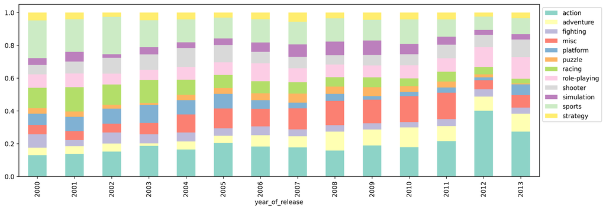

```
Вышедших игр в жанре RPG
```

| year_of_release | Кол-во | Доля |
| --- | --- | --- |
| 2000 | 29 | 8.22% |
| 2001 | 41 | 8.33% |
| 2002 | 56 | 6.59% |
| 2003 | 49 | 6.22% |
| 2004 | 60 | 7.78% |
| 2005 | 74 | 7.75% |
| 2006 | 111 | 10.83% |
| 2007 | 103 | 8.52% |
| 2008 | 112 | 7.75% |
| 2009 | 106 | 7.35% |
| 2010 | 103 | 8.02% |
| 2011 | 96 | 8.21% |
| 2012 | 80 | 12.12% |
| 2013 | 72 | 13.14% |

```python
temp = df_actual.groupby(["genre", "year_of_release"])["name"].count().unstack("genre")
temp.apply(
    lambda x: x / x.sum(), axis=1
).plot(figsize=(15, 5), kind="bar", colormap='Set3', stacked=True)
plt.legend(loc='upper left', bbox_to_anchor=(1, 1))
plt.show()
print("Вышедших игр в жанре RPG")
pd.concat(
    [
        temp["role-playing"].rename("Кол-во"),
        (temp["role-playing"] / temp.sum(axis=1)).rename("Доля"),
    ],
    axis=1,
).style.format("{:.2%}", subset="Доля")
```

Есть тенденция к увеличению выхода игр в жанре RPG с 2000 по 2013 год

**Популярность жанра RPG у покупателей (доля проданных копий игр в процентах от всех проданных игр в разрезе года выпуска)**

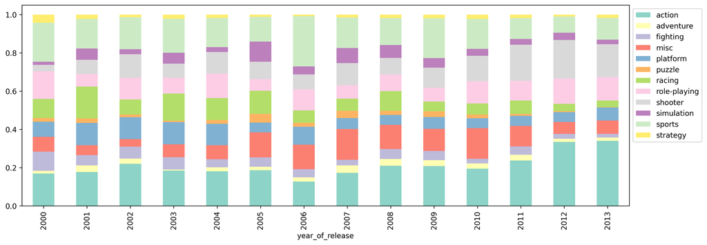

```
Проданных копий в жанре RPG
```

| year_of_release | Кол-во | Доля |
| --- | --- | --- |
| 2000 | 29.049999 | 14.37% |
| 2001 | 22.020000 | 6.55% |
| 2002 | 46.110001 | 11.42% |
| 2003 | 30.389999 | 8.25% |
| 2004 | 53.959999 | 12.84% |
| 2005 | 28.500000 | 6.14% |
| 2006 | 58.000000 | 11.07% |
| 2007 | 43.459999 | 7.08% |
| 2008 | 58.980000 | 8.64% |
| 2009 | 47.380001 | 7.18% |
| 2010 | 69.650002 | 11.66% |
| 2011 | 53.250000 | 10.25% |
| 2012 | 47.200001 | 13.24% |
| 2013 | 44.500000 | 12.30% |

```python
df_actual['total_sales'] = df_actual.filter(like="_sales").sum(axis=1)
temp = df_actual.groupby(["genre", "year_of_release"])["total_sales"].sum().unstack("genre")
temp.apply(
    lambda x: x / x.sum(), axis=1
).plot(figsize=(15, 5), kind="bar", colormap='Set3', stacked=True)
plt.legend(loc='upper left', bbox_to_anchor=(1, 1))
plt.show()
print("Проданных копий в жанре RPG")
pd.concat(
    [
        temp["role-playing"].rename("Кол-во"),
        (temp["role-playing"] / temp.sum(axis=1)).rename("Доля"),
    ],
    axis=1,
).style.format("{:.2%}", subset="Доля")
```

Нельзя однозначно сказать, что популярность RPG среди игроков относительно других жанров растёт со временем

**Популярность жанра RPG у покупателей (доля проданных копий игр в процентах от всех проданных игр в разрезе платформы)**

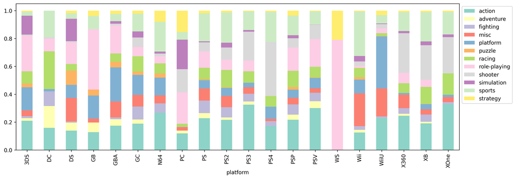

```
Проданных копий в жанре RPG
```

| platform | Проданных копий | Доля |
| --- | --- | --- |
| WS | 0.760000 | 79.17% |
| GB | 12.559999 | 43.31% |
| 3DS | 44.209999 | 25.67% |
| PC | 41.180000 | 22.59% |
| GBA | 64.199997 | 20.22% |
| PSV | 6.310000 | 19.92% |
| PSP | 48.900002 | 16.66% |
| DS | 124.279999 | 15.42% |
| PS | 16.780001 | 11.86% |
| DC | 0.680000 | 9.18% |
| PS3 | 67.080002 | 7.70% |
| X360 | 68.629997 | 7.44% |
| PS2 | 93.239998 | 7.43% |
| GC | 13.160000 | 6.62% |
| XB | 13.509999 | 5.24% |
| N64 | 1.890000 | 5.05% |
| WiiU | 1.370000 | 3.49% |
| Wii | 13.710000 | 1.52% |
| PS4 | 0.000000 | 0.00% |
| XOne | 0.000000 | 0.00% |

```python
temp = df_actual.groupby(["genre", "platform"])['total_sales'].sum().unstack("genre")
temp = temp[temp.sum(axis=1) != 0]
temp.apply(
    lambda x: x / x.sum(), axis=1
).plot(figsize=(15, 5), kind="bar", colormap='Set3', stacked=True)
plt.legend(loc='upper left', bbox_to_anchor=(1, 1))
plt.show()
print("Проданных копий в жанре RPG")
pd.concat(
    [
        temp["role-playing"].rename("Проданных копий"),
        (temp["role-playing"] / temp.sum(axis=1)).rename("Доля"),
    ],
    axis=1,
).sort_values('Доля', ascending=False).style.format("{:.2%}", subset="Доля")
```

- жанр RPG был очень популярен на 3DS, GameBoy и GameBoy Advanced, до сих пор пупулярен на PC
- низкие показатели PS4 и Xbox One обусловлены выходом этих платформ в ноябре 2013 года.

**Региональные предпочтения игроков в разрезе игровых платформ**

```
na_sales
```

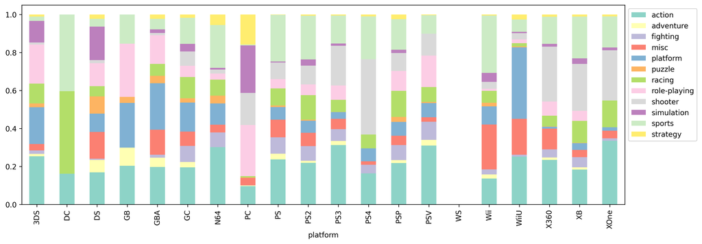

```
eu_sales
```

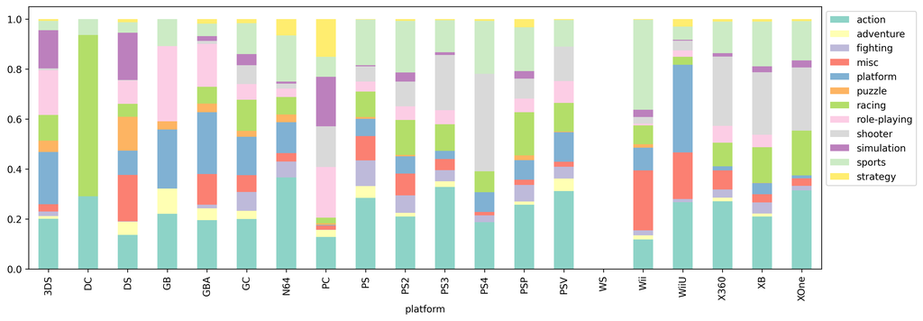

```
jp_sales
```

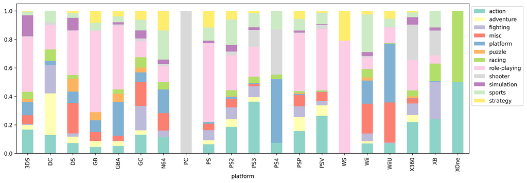

```
other_sales
```

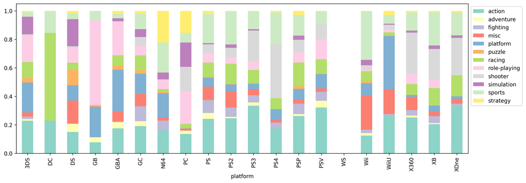

```
Проданных копий в жанре RPG
```

| country metric platform | na_sales Проданных копий | na_sales Доля | eu_sales Проданных копий | eu_sales Доля | jp_sales Проданных копий | jp_sales Доля | other_sales Проданных копий | other_sales Доля |
| --- | --- | --- | --- | --- | --- | --- | --- | --- |
| 3DS | 12.52 | 20.60% | 8.09 | 17.84% | 21.80 | 38.63% | 1.80 | 18.61% |
| DC | 0.00 | 0.00% | 0.00 | 0.00% | 0.68 | 17.17% | 0.00 | 0.00% |
| DS | 46.14 | 12.07% | 17.47 | 9.25% | 54.38 | 31.02% | 6.29 | 10.61% |
| GB | 2.55 | 27.96% | 1.56 | 30.06% | 7.45 | 57.26% | 1.00 | 59.52% |
| GBA | 28.29 | 15.08% | 12.87 | 17.17% | 21.21 | 44.81% | 1.83 | 23.67% |
| GC | 7.91 | 5.93% | 2.44 | 6.30% | 2.47 | 11.45% | 0.34 | 6.56% |
| N64 | 0.70 | 3.18% | 0.21 | 3.41% | 0.91 | 11.03% | 0.07 | 6.73% |
| PC | 15.57 | 26.91% | 21.28 | 20.20% | 0.00 | 0.00% | 4.33 | 22.78% |
| PS | 3.24 | 4.90% | 1.88 | 3.98% | 11.12 | 55.32% | 0.54 | 6.75% |
| PS2 | 32.77 | 5.62% | 18.36 | 5.42% | 33.86 | 24.38% | 8.25 | 4.27% |
| PS3 | 27.92 | 7.52% | 16.98 | 5.58% | 14.41 | 20.90% | 7.77 | 6.15% |
| PS4 | 0.00 | 0.00% | 0.00 | 0.00% | 0.00 | 0.00% | 0.00 | 0.00% |
| PSP | 11.46 | 10.50% | 3.64 | 5.46% | 30.82 | 40.45% | 2.98 | 7.19% |
| PSV | 1.67 | 16.60% | 0.83 | 8.65% | 3.16 | 42.88% | 0.65 | 13.98% |
| WS | 0.00 | nan% | 0.00 | nan% | 0.76 | 79.17% | 0.00 | nan% |
| Wii | 5.48 | 1.11% | 1.88 | 0.72% | 5.63 | 8.13% | 0.72 | 0.92% |
| WiiU | 0.38 | 2.03% | 0.30 | 2.50% | 0.63 | 11.05% | 0.06 | 2.15% |
| X360 | 43.03 | 7.49% | 17.10 | 6.70% | 2.59 | 21.11% | 5.91 | 7.26% |
| XB | 9.89 | 5.30% | 3.04 | 4.99% | 0.08 | 5.80% | 0.50 | 5.73% |
| XOne | 0.00 | 0.00% | 0.00 | 0.00% | 0.00 | 0.00% | 0.00 | 0.00% |

| country metric | na_sales Проданных копий | na_sales Доля | eu_sales Проданных копий | eu_sales Доля | jp_sales Проданных копий | jp_sales Доля | other_sales Проданных копий | other_sales Доля |
| --- | --- | --- | --- | --- | --- | --- | --- | --- |
| Total | 249.52 | 16.54% | 127.93 | 14.19% | 211.96 | 49.84% | 43.04 | 19.43% |

```python
sales_columns = ["na_sales", "eu_sales", "jp_sales", "other_sales"]
temp = df_actual.groupby(["genre", "platform"])[sales_columns].sum().unstack("genre")
temp = temp[temp.sum(axis=1) != 0]
for column in sales_columns:
    print(f"{column}")
    temp[column].apply(lambda x: x / x.sum(), axis=1).plot(
        figsize=(15, 5), kind="bar", colormap="Set3", stacked=True
    )
    plt.legend(loc="upper left", bbox_to_anchor=(1, 1))
    plt.show()
print("Проданных копий в жанре RPG")

stats = []
for column in sales_columns:
    stats.append(
        pd.concat(
            [
                temp[column]["role-playing"],
                temp[column]["role-playing"] / temp[column].sum(axis=1),
            ],
            keys=[(column, "Проданных копий"), (column, "Доля")],
            names=["country", "metric"],
            axis=1,
        )
    )

subset = [(col, 'Доля') for col in sales_columns]
stats_df = pd.concat(stats, axis=1)
total_rpg_sales = stats_df[subset].sum().sum()
summary = pd.DataFrame(stats_df.apply(lambda x: x.sum() if x.name[1] == 'Проданных копий' else x.sum() / total_rpg_sales)).T
summary = summary.rename(index={0: 'Total'})

# summary_styler = summary.
display(stats_df.style.format("{:.2f}").format("{:.2%}", subset=subset))
display(summary.style.format("{:.2f}").format("{:.2%}", subset=subset))
```

- RPG занимают половину японского рынка видеоигр, но в абсолютном выражении всё равно отстают от Северной Америки.
- игры на PC в Японии практически не продаются

## 5. Итоговый вывод

- Мы обработали исходный датасет, удалили дубликаты, заменили недостающие значения, привели типы и нормализовали.
- Провели базовую аналитику и ответили на поставленные вопросы. В дальнейшем имеет смысл изучить влияние оценок критиков/пользователей и возрастного рейтинга на продажи в различных регионах.
- Стоит обратить внимание, что датасет скорее всего не содержит онлайн-продаж, потому что количество вышедших игр снижается после 2009 года, что скорее всего исключает игры в электронном виде.